# 00_all

## Full project

This is joined quarto document, that runs all project steps.

This is document for loading of raw data. Theoretically it is possible to work directly on raw data files, but it is good practice to separate steps of work, i.e. saving files after each step separately rather than overwriting them. In practice this allows to save time if some actions need to be retracted. Furthermore it is much cleaner and allows better overview.

## Loading of the raw data

To proceed with reading of raw data libraries needed for that are loaded

```r
library("tidyverse")
library("here")
```

To read the file, name of it is needed.

```r
name_raw = "paad_tcga_pan_can_atlas_2018_clinical_data.tsv"
```

With the name, the main file can be loaded and then saved in proper place (data folder). It ensures that work is never done on the raw data.

```r
read_tsv(here("_raw",name_raw)) |>
  write_tsv(x = _,file = here("data","data_load.tsv"))
```

In this document raw data is prepared for further processing. This includes dropping redundant columns, filtering outliers and separating data into smaller parts.

## Loading libraries

For any work to proceed, first libraries need to be loaded

```r
library("tidyverse")
library("here")
```

## Loading the data

To process data it first needs to be loaded into memory.

```r
data <- read_tsv(here("data","data_load.tsv"))
```

## Dropping redundant data

First step is to get data information for further processing

```r
num_obs <-  nrow(data)
```

Some (in this case one) of the columns might come fully empty and impact data processing and analysis. Such columns need to be found and dropped.

```r
empty_col <-  data|>
  map(~all(is.na(.)))|>
  enframe()|>
  pivot_wider()|>
  select(where(~all (. == TRUE)))|>
  colnames()
data <- data|>
  select(-all_of(empty_col))
```

For the ability to easily navigate through changes (splits and joins) it needs to be checked if the Patient ID is unique identifier for each observation.

```r
data|>
  select("Patient ID")|>
  n_distinct() == num_obs
```

```
[1] TRUE
```

If other IDs are all unique, then they are redundant and can be dropped.

```r
data|>
  select("Sample ID")|>
  n_distinct() == num_obs
```

```
[1] TRUE
```

```r
data|>
  select("Other Patient ID")|>
  n_distinct() == num_obs
```

```
[1] TRUE
```

```r
redundantIDs <- c("Sample ID","Other Patient ID")
```

If some information is the same for all observations then there is no need to keep it for any further processing as it is redundant to keep it here for analysis.

```r
names_red_col <- data|>
  map(~ n_distinct(.,na.rm=TRUE))|>
  enframe()|>
  pivot_wider()|>
  select(where(~all (. == 1)))|>
  colnames()
```

Redundant data is dropped to save space for processing.

```r
#redundant data is dropped
data_red <- data|>
  select(-all_of(names_red_col))|>
  select(-all_of(redundantIDs))
#showing dropped value of redundant columns
data|>
  select(all_of(names_red_col))|>
  slice(1)|>
  mutate(across(everything(), as.character))|>
  pivot_longer(
    cols = everything(),
    names_to = "Redundant features",
    values_to = "Singular value",
  )
```

```
# A tibble: 13 × 2
   `Redundant features`                                         `Singular value`
   <chr>                                                        <chr>
 1 Study ID                                                     paad_tcga_pan_c…
 2 Cancer Type                                                  Pancreatic Canc…
 3 TCGA PanCanAtlas Cancer Type Acronym                         PAAD
 4 Cancer Type Detailed                                         Pancreatic Aden…
 5 Last Alive Less Initial Pathologic Diagnosis Date Calculate… 0
 6 Neoadjuvant Therapy Type Administered Prior To Resection Te… No
 7 Informed consent verified                                    Yes
 8 Oncotree Code                                                PAAD
 9 Number of Samples Per Patient                                1
10 Sample Type                                                  Primary
11 Somatic Status                                               Matched
12 Subtype                                                      PAAD
13 Tumor Disease Anatomic Site                                  Pancreas
```

## Filtering outliers

During the analysis some outliers were identified. As they impact analysis negatively there is need to filter them out.

```r
data_red <-  data_red|>
  filter(
    `Mutation Count` < 5000,
    `TMB (nonsynonymous)` < 400)
```

## Separating data

Used data has many features, which makes working on it harder. Fortunately data can be split into subcategories, which would make its processing and analysis easier. Observations in different tables would be identifiable by Patient ID.

```r
colnames(data_red)
```

```
 [1] "Patient ID"
 [2] "Diagnosis Age"
 [3] "Neoplasm Disease Stage American Joint Committee on Cancer Code"
 [4] "American Joint Committee on Cancer Publication Version Type"
 [5] "Aneuploidy Score"
 [6] "Buffa Hypoxia Score"
 [7] "Last Communication Contact from Initial Pathologic Diagnosis Date"
 [8] "Birth from Initial Pathologic Diagnosis Date"
 [9] "Disease Free (Months)"
[10] "Disease Free Status"
[11] "Months of disease-specific survival"
[12] "Disease-specific Survival status"
[13] "Ethnicity Category"
[14] "Form completion date"
[15] "Fraction Genome Altered"
```

[output cut: 32 more lines]

Data table is split into tables based on subcategory columns belong to. Furthermore irrelevant features are not selected to any subcategory, so they are effectively dropped.

```r
met_cols <- c("Diagnosis Age","Sex","Genetic Ancestry Label"
              ,"Race Category","Ethnicity Category"  )
data_metrics <- data_red|>
  select(c("Patient ID",all_of(met_cols)))

gene_cols <- c("Fraction Genome Altered", "Mutation Count",
               "TMB (nonsynonymous)", "Tumor Break Load"  )
data_gene <- data_red|>
  select(c("Patient ID",all_of(gene_cols)))

score_cols <- c("Aneuploidy Score",  "Buffa Hypoxia Score",
                "MSI MANTIS Score", "MSIsensor Score",
                "Ragnum Hypoxia Score", "Winter Hypoxia Score",
                "Tissue Source Site Code")
data_score <- data_red|>
  select(c("Patient ID",all_of(score_cols)))

code_cols <- c("Neoplasm Disease Stage American Joint Committee on Cancer Code",
               "International Classification of Diseases for Oncology, Third Edition ICD-O-3 Histology Code",
               "International Classification of Diseases for Oncology, Third Edition ICD-O-3 Site Code",
               "American Joint Committee on Cancer Metastasis Stage Code",
               "Neoplasm Disease Lymph Node Stage American Joint Committee on Cancer Code",
               "American Joint Committee on Cancer Tumor Stage Code" )
data_code <- data_red|>
  select(c("Patient ID",all_of(code_cols)))

diag_cols <- c("Tumor Type", "Overall Survival (Months)",
               "Overall Survival Status",
               "Months of disease-specific survival",
               "Disease-specific Survival status",
               "Disease Free (Months)", "Disease Free Status",
               "Progress Free Survival (Months)" ,
               "Progression Free Status", "Prior Diagnosis",
               "Radiation Therapy",
               "Primary Lymph Node Presentation Assessment",
               "Person Neoplasm Cancer Status",
               "New Neoplasm Event Post Initial Therapy Indicator" ,
               "Neoplasm Histologic Grade", "ICD-10 Classification")
data_diag <- data_red|>
  select(c("Patient ID",all_of(diag_cols)))
```

## Saving data

To have clean task separation, progress is saved and loaded in further processing. In case of some mistake, the data don’t have to be rolled back (and operations on it) from the beginning. In effect this saves time in despite of need for some additional operations (loading and saving).

```r
write_tsv(x = data_metrics,file = here("data","data_metrics.tsv"))
write_tsv(x = data_gene,file = here("data","data_gene.tsv"))
write_tsv(x = data_score,file = here("data","data_score.tsv"))
write_tsv(x = data_code,file = here("data","data_code.tsv"))
write_tsv(x = data_diag,file = here("data","data_diag.tsv"))
```

This part of project is focused on getting more data from raw data (data earlier processed in cleaning, but cleaning was focus on dropping data, so it is in the same way as in raw form). While doing so data is tidied. Furthermore some units are changed into more suitable for analysis.

## Loading libraries

For any work to proceed, first libraries need to be loaded

```r
library("tidyverse")
library("here")
```

## Loading the data

To process data it first needs to be loaded into memory. Even if some tables are not processed in this segment they will be loaded to be saved under different name for the sake of naming convention. In this case, advantages of clearing the ambiguity are higher than that of saving resources.

```r
data_metrics <- read_tsv(here("data","data_metrics.tsv"))
data_gene <- read_tsv(here("data","data_gene.tsv"))
data_score <- read_tsv(here("data","data_score.tsv"))
data_code <- read_tsv(here("data","data_code.tsv"))
data_diag <- read_tsv(here("data","data_diag.tsv"))
```

## Adding Age Group

The data set is not big enough to treat all ages as separate categories. For this reason and for better clarity (7 groups are easier to analyze than 70) bigger groups are created. In this case they are intervals of 10 years in ages 20-90 (some of them might be empty).

```r
data_metrics <- data_metrics |>
  mutate(Age_Group = cut(
    `Diagnosis Age`,
    breaks = seq(20, 90, by = 10),
    right = FALSE))
```

## Changing units from months to days

Operating in months as unit is strange and not intuitive for analysis. For this reason units of some columns are changed from months to days. Unfortunately multiplying by average of days per month (or any nearby integer 28-31) does not results in integer number of days. For this reason results are rounded to represent full day as base unit. All loss resulted in this operation should be negligible in comparison to benefits of change.

```r
months_to_days <- (7*31+28.25+4*30)/12
data_diag_units <- data_diag|>
  mutate(`Overall Survival (days)` =
           round(`Overall Survival (Months)` * months_to_days),
         `Disease Free (days)` = round(`Disease Free (Months)` * months_to_days),
         `Progress Free Survival (days)` =
           round(`Progress Free Survival (Months)` * months_to_days),
         `Days of disease-specific survival` =  round(`Months of disease-specific survival` * months_to_days),
  )
```

## Splitting the columns

Some columns contain both numeric and descriptive information as strings. For further clear processing and tiding this data is separated. Additionally it is ensured that data type is numeric for numeric parts.

```r
#as first step data needs to be split
data_diag_separate <- data_diag_units|>
  separate(col = `Overall Survival Status`,
           into = c("Overall Survival Status (bin)",
                    "Overall Survival Status (des)"),
           sep = ":",
           convert = TRUE
  )|>
  separate(col = `Disease-specific Survival status`,
           into = c("Disease-specific Survival status (bin)",
                    "Disease-specific Survival status (des)"),
           sep = ":",
           convert = TRUE
   )|>
  separate(col = `Disease Free Status`,
           into = c("Disease Free Status (bin)",
                    "Disease Free Status (des)"),
           sep = ":",
           convert = TRUE
   )|>
  separate(col = `Progression Free Status`,
           into = c("Progression Free Status (bin)",
                    "Progression Free Status (des)"),
           sep = ":",
           convert = TRUE
   )
```

## Saving the data

As before to have clean task separation, progress is saved and loaded in further processing. Furthermore, as earlier mentioned, data is saved (with different name) even if it was not processed in this segment.

```r
write_tsv(x = data_metrics,file = here("data","data_metrics_aug.tsv"))
write_tsv(x = data_gene,file = here("data","data_gene_aug.tsv"))
write_tsv(x = data_score,file = here("data","data_score_aug.tsv"))
write_tsv(x = data_code,file = here("data","data_code_aug.tsv"))
write_tsv(x = data_diag_separate,file = here("data","data_diag_aug.tsv"))
```

## **Loading libraries**

```r
library("tidyverse")
library("here")  #non-tidyverse
library("ggalluvial")  #non-tidyverse; for the very last plot - optional add-on
```

## **Loading data**

Loading the data from the previous augmentation step *03_augment*.

```r
data_metrics <- read_tsv(here("data","data_metrics_aug.tsv"))
data_gene <- read_tsv(here("data","data_gene_aug.tsv"))
data_score <- read_tsv(here("data","data_score_aug.tsv"))
data_code <- read_tsv(here("data","data_code_aug.tsv"))
data_diag <- read_tsv(here("data","data_diag_aug.tsv"))
```

## Inspecting the data and data categories

```r
#view the structure of the data metrics
glimpse(data_metrics)
```

```
Rows: 173
Columns: 7
$ `Patient ID`             <chr> "TCGA-2J-AAB1", "TCGA-2J-AAB4", "TCGA-2J-AAB6…
$ `Diagnosis Age`          <dbl> 65, 48, 75, 71, 70, 55, 73, 73, 61, 55, 71, 4…
$ Sex                      <chr> "Male", "Male", "Male", "Male", "Female", "Ma…
$ `Genetic Ancestry Label` <chr> "EUR", "EUR", "EUR", "EUR", "EUR", "EUR", "EU…
$ `Race Category`          <chr> "White", "White", "White", "White", "White", …
$ `Ethnicity Category`     <chr> NA, NA, NA, NA, NA, NA, NA, NA, NA, NA, NA, N…
$ Age_Group                <chr> "[60,70)", "[40,50)", "[70,80)", "[70,80)", "…
```

```r
#define the data metrics columns
metric_cols <- c(
  "Diagnosis Age",
  "Sex",
  "Genetic Ancestry Label",
  "Race Category",
  "Ethnicity Category"
)
```

```r
glimpse(data_gene)
```

```
Rows: 173
Columns: 5
$ `Patient ID`              <chr> "TCGA-2J-AAB1", "TCGA-2J-AAB4", "TCGA-2J-AAB…
$ `Fraction Genome Altered` <dbl> 0.0697, 0.1518, 0.3743, 0.0662, 0.0043, 0.09…
$ `Mutation Count`          <dbl> 62, 27, 60, 43, 13, 32, 30, 45, 37, 30, 35, …
$ `TMB (nonsynonymous)`     <dbl> 2.0666667, 0.9333333, 1.9666667, 1.4333333, …
$ `Tumor Break Load`        <dbl> 13, 39, 84, 60, 24, 11, 19, 67, 35, 18, 42, …
```

```r
#name the dataset columns for the gene dataset
gene_cols <- c(
  "Tumor Break Load",
  "Fraction Genome Altered",
  "Mutation Count",
  "TMB (nonsynonymous)"
)
```

```r
glimpse(data_score)
```

```
Rows: 173
Columns: 8
$ `Patient ID`              <chr> "TCGA-2J-AAB1", "TCGA-2J-AAB4", "TCGA-2J-AAB…
$ `Aneuploidy Score`        <dbl> 2, 6, 13, 9, 0, 6, 5, 9, 11, 13, NA, 22, 18,…
$ `Buffa Hypoxia Score`     <dbl> -25, 1, 23, -23, -27, -31, -27, -19, -15, 13…
$ `MSI MANTIS Score`        <dbl> 0.2792, 0.2835, 0.2974, 0.2788, 0.2722, 0.27…
$ `MSIsensor Score`         <dbl> 1.42, 0.23, 0.72, 1.01, 0.51, 0.61, 1.57, 0.…
$ `Ragnum Hypoxia Score`    <dbl> -16, -2, 10, -2, -14, -12, -12, -4, -16, 14,…
$ `Winter Hypoxia Score`    <dbl> -24, 0, 48, -6, -16, -22, -18, -16, 0, 22, -…
$ `Tissue Source Site Code` <chr> "2J", "2J", "2J", "2J", "2J", "2J", "2J", "2…
```

```r
#name the dataset columns for the score dataset
score_cols <- c(
  "Aneuploidy Score",
  "MSI MANTIS Score",
  "MSIsensor Score",
  "Buffa Hypoxia Score",
  "Ragnum Hypoxia Score",
  "Winter Hypoxia Score"
)
```

```r
glimpse(data_code)
```

```
Rows: 173
Columns: 7
$ `Patient ID`                                                                                  <chr> …
$ `Neoplasm Disease Stage American Joint Committee on Cancer Code`                              <chr> …
$ `International Classification of Diseases for Oncology, Third Edition ICD-O-3 Histology Code` <chr> …
$ `International Classification of Diseases for Oncology, Third Edition ICD-O-3 Site Code`      <chr> …
$ `American Joint Committee on Cancer Metastasis Stage Code`                                    <chr> …
$ `Neoplasm Disease Lymph Node Stage American Joint Committee on Cancer Code`                   <chr> …
$ `American Joint Committee on Cancer Tumor Stage Code`                                         <chr> …
```

```r
#rename variables to short form for easy display
code_vars <- c(
  "Neoplasm AJCC" = "Neoplasm Disease Stage American Joint Committee on Cancer Code",
  "ICD-O-3 Histology" = "International Classification of Diseases for Oncology, Third Edition ICD-O-3 Histology Code",
  "ICD-O-3 Site" = "International Classification of Diseases for Oncology, Third Edition ICD-O-3 Site Code",
  "AJCC Metastasis" = "American Joint Committee on Cancer Metastasis Stage Code",
  "Neoplasm Lymph AJCC" = "Neoplasm Disease Lymph Node Stage American Joint Committee on Cancer Code",
  "AJCC Tumor" = "American Joint Committee on Cancer Tumor Stage Code"
)
```

```r
glimpse(data_diag)
```

```
Rows: 173
Columns: 25
$ `Patient ID`                                        <chr> "TCGA-2J-AAB1", "T…
$ `Tumor Type`                                        <chr> "Pancreas Adenocar…
$ `Overall Survival (Months)`                         <dbl> 2.169839, 23.96686…
$ `Overall Survival Status (bin)`                     <dbl> 1, 0, 1, 0, 1, 1, …
$ `Overall Survival Status (des)`                     <chr> "DECEASED", "LIVIN…
$ `Months of disease-specific survival`               <dbl> 2.169839, 23.96686…
$ `Disease-specific Survival status (bin)`            <dbl> 1, 0, 1, 0, 1, 1, …
$ `Disease-specific Survival status (des)`            <chr> "DEAD WITH TUMOR",…
$ `Disease Free (Months)`                             <dbl> 2.169839, 23.96686…
$ `Disease Free Status (bin)`                         <dbl> 0, 0, NA, NA, 1, N…
$ `Disease Free Status (des)`                         <chr> "DiseaseFree", "Di…
$ `Progress Free Survival (Months)`                   <dbl> 2.169839, 23.96686…
$ `Progression Free Status (bin)`                     <dbl> 0, 0, 1, 0, 1, 1, …
$ `Progression Free Status (des)`                     <chr> "CENSORED", "CENSO…
$ `Prior Diagnosis`                                   <chr> "No", "No", "No", …
$ `Radiation Therapy`                                 <chr> "No", "No", "No", …
$ `Primary Lymph Node Presentation Assessment`        <chr> "Yes", "Yes", "Yes…
$ `Person Neoplasm Cancer Status`                     <chr> "Tumor Free", "Tum…
$ `New Neoplasm Event Post Initial Therapy Indicator` <chr> "No", "No", "Yes",…
$ `Neoplasm Histologic Grade`                         <chr> "G3", "G2", "G2", …
$ `ICD-10 Classification`                             <chr> "C25.0", "C25.8", …
$ `Overall Survival (days)`                           <dbl> 66, 729, 293, 80, …
$ `Disease Free (days)`                               <dbl> 66, 729, NA, NA, 5…
$ `Progress Free Survival (days)`                     <dbl> 66, 729, 169, 80, …
$ `Days of disease-specific survival`                 <dbl> 66, 729, 293, 80, …
```

```r
#----- numerical data
diagnosis_list_numeric <- data_diag |>
  select(
    "Overall Survival (days)",
    "Overall Survival (Months)",
    "Disease Free (Months)",
    "Disease Free (days)",
    "Progress Free Survival (Months)",
    "Progress Free Survival (days)"
  )

#----- categorical data
top_vars <- c(
  "Overall Survival Status (des)",
  "Disease-specific Survival status (des)",
  "Disease Free Status (des)",
  "Progression Free Status (des)",
  "Prior Diagnosis",
  "Radiation Therapy"
)

bottom_vars <- c(
  "Tumor Type",
  "Primary Lymph Node Presentation Assessment",
  "Person Neoplasm Cancer Status",
  "New Neoplasm Event Post Initial Therapy Indicator",
  "Neoplasm Histologic Grade",
  "ICD-10 Classification"
)
```

## Summary of Patient Metadata Metrics

Plot the metrics, the number of metrics, the types within the metrics, and the values within each types. Males exhibit a higher mean age at diagnosis compared to females. Age groups of [30,40] and [80,90] contain too few individuals to support meaningful statistical analysis. Race, Genetic Ancestry Label, and Ethnicity Category strongly overlap in our data, with most individuals of European ancestry also classified as White and similar by ethnicity. This high correlation limits diversity across subgroups, rendering analyses stratified by these categories unreliable for drawing meaningful conclusions, except if limited to White European.

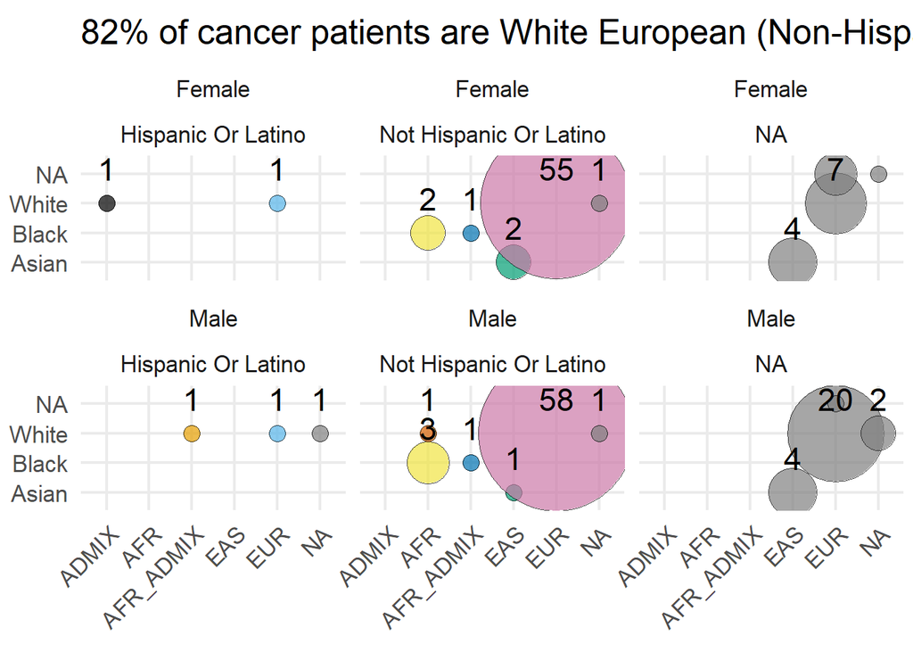

```r
#recode "Black or African American" = "Black"
data_metrics <- data_metrics |>
  mutate(
    `Race Category` = recode(
      `Race Category`,
      "Black or African American" = "Black"))


#----- bubble plot for cross-category frequencies
data_metrics |>

  #count entries in each category
  count(
    Sex,
    `Genetic Ancestry Label`,
    `Race Category`,
    `Ethnicity Category`
  )|>
  ggplot(
    aes(
      x = `Genetic Ancestry Label`,
      y = `Race Category`,
      size = n
    )
  ) +
  geom_point(
    aes(
      fill = interaction(
        `Genetic Ancestry Label`,
        `Race Category`,
        `Ethnicity Category`
      )
    ),
    color = "black",
    shape = 21,
    stroke = 0.5,
    alpha = 0.7
  ) +
  geom_text(
    aes(label = n),
    color = "black",
    vjust = -1,
    size = 6
  ) +
  facet_wrap(
    Sex ~ `Ethnicity Category`
  ) +
  scale_size(range = c(4, 40)) +
  scale_fill_manual(
    values = c(
      "#000000", "#E69F00", "#56B4E9", "#009E73",
      "#F0E442", "#0072B2", "#D55E00", "#CC79A7"
    )
  ) +
  labs(
    title = "82% of cancer patients are White European (Non-Hispanic/Latino or Other)",
    size = "Count",
    x = NULL,
    y = NULL
  ) +
  theme_minimal(base_size = 16) +
  theme(
    axis.text.x = element_text(angle = 45, hjust = 1),
    legend.box = "vertical",
    legend.position = "none",
    plot.margin = margin(t = 10, r = 5, b = 10, l = 5))
```

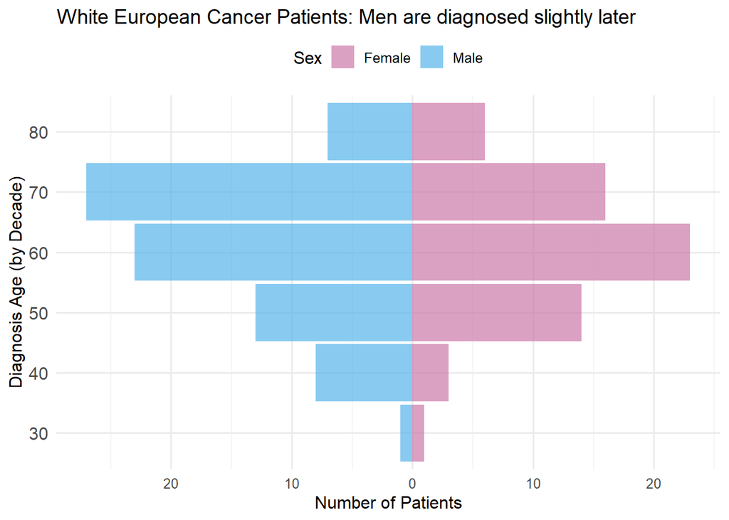

```r
#----- age pyramid plot males vs females
#filter EUR AND White and count, pass to ggplot
data_metrics |>
  filter(
    `Genetic Ancestry Label` == "EUR",
    `Race Category` == "White"
  )|>
  mutate(
    AgeDecade = floor(
      `Diagnosis Age` / 10) * 10
  )|>
  count(
    Sex,
    AgeDecade,
    name = "Count"
  )|>
  mutate(
    Count = ifelse(Sex == "Male", -Count, Count)
  )|>
ggplot(
  aes(
    x = Count,
    y = factor(AgeDecade),
    fill = Sex
    )
  ) +
  geom_col(
    width = 0.95,
    alpha = 0.7
  ) +
  scale_fill_manual(
    values = c(
      "Male" = "#56B4E9",
      "Female" = "#CC79A7"
      )
    ) +
  scale_x_continuous(
    breaks = scales::pretty_breaks(6),
    labels = abs
  ) +
  labs(
    title = "White European Cancer Patients: Men are diagnosed slightly later",
    x = "Number of Patients",
    y = "Diagnosis Age (by Decade)"
  ) +
  theme_minimal(base_size = 12) +
  theme(
    legend.position = "top",
    plot.title = element_text(size = 14),
    axis.text.y = element_text(size = 12)
  )
```

## **Summary of Tumor Genetics (gene) and Scoring (score)**

Fraction Genome Altered: The proportion of the tumor’s genome with copy number gains or losses, reflecting the extent of chromosomal instability present in the cancer cells. Mutation Count: The total number of mutations identified in the tumor genome, typically including single-nucleotide variants and small insertions/deletions. TMB (nonsynonymous): Tumor Mutation Burden (TMB) is the number of nonsynonymous mutations (those that change protein sequences) per megabase of DNA in the tumor, and is used to estimate overall mutational load. Tumor Break Load: The quantity or extent of structural variants in the tumor genome, representing breaks or major rearrangements, which indicate higher genomic instability in the tumor.

Aneuploidy scores show the extent of large chromosomal alterations (copy number) in the tumors. The MSI/microsatellites scores quantify how many errors have accumulated in these regions (which are error-prone during DNA replication). The hypoxia scores quantify epigenetic-based upregulation of genes in tumors that enable them to adapt to hypoxia/low-oxygen environments - high hypoxia scores are associated with poorer outcomes.

```
Ignoring unknown labels:
• colour : "Metric"
```

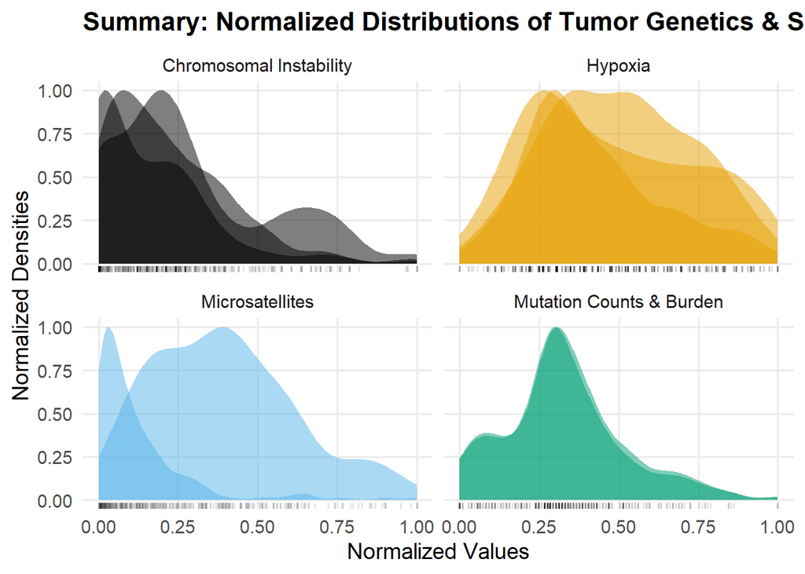

```r
#----- dataframe treatment for the gene dataset
#pivot to long dataframe for plotting
gene_long <- data_gene |>
  select(all_of(gene_cols)) |>
  pivot_longer(
    cols = everything(),
    names_to = "Category",
    values_to = "Value"
  )

gene_long <- gene_long |>
  mutate(
    Category = recode(
      Category,
      `TMB (nonsynonymous)` = "Tumor Mutation Burden"
    )
  )

#remove a single extreme outlier and normalize for all four categories
gene_no_ext_norm <- gene_long |>
  group_by(Category) |>
  filter(row_number(desc(Value)) > 1) |>
  mutate(
    NormValue = (Value - min(Value, na.rm = TRUE)) /
      (max(Value, na.rm = TRUE) - min(Value, na.rm = TRUE))
  ) |>
  ungroup()

#----- dataframe treatment for the score dataset
score_long <- data_score |>
  select(all_of(score_cols)) |>
  mutate(across(everything(), as.numeric)) |>
  pivot_longer(
    cols = everything(),
    names_to = "Score",
    values_to = "Value"
  )

score_no_ext_norm <- score_long |>
  group_by(Score) |>
  filter(Value != max(Value, na.rm = TRUE)) |>
  mutate(
    NormValue = (Value - min(Value, na.rm = TRUE)) /
      (max(Value, na.rm = TRUE) - min(Value, na.rm = TRUE))
  ) |>
  ungroup() |>
  rename(Category = Score)


#----- combined density plot
#combine dataset categories for genes and scores
combined_norm <- bind_rows(
  gene_no_ext_norm |> select(Category, Value, NormValue),
  score_no_ext_norm |> select(Category, Value, NormValue)
)

#make groups by data structure and category for ggplot density plots below
combined_norm <- combined_norm |>
  mutate(
    Group = case_when(
      Category %in% c(
        "Aneuploidy Score",   #NOTE - ANEUPLOIDY MOVED HERE FROM DATA_SCORE!!!
        "Tumor Break Load",
        "Fraction Genome Altered"
      ) ~ "Chromosomal Instability",

       Category %in% c(
        "Mutation Count",
        "Tumor Mutation Burden"
      ) ~ "Mutation Counts & Burden",

      Category %in% c(
        "MSI MANTIS Score",
        "MSIsensor Score"
      ) ~ "Microsatellites",

      Category %in% c(
        "Buffa Hypoxia Score",
        "Ragnum Hypoxia Score",
        "Winter Hypoxia Score"
      ) ~ "Hypoxia",

      TRUE ~ "Other"
    )
  )

#general overview plot with normalized gene and score categories
ggplot(combined_norm, aes(x = NormValue)) +
  geom_density(
    aes(
      y = after_stat(scaled),
      fill = Group,
      group = Category
    ),
    color = NA,
    alpha = 0.5,
    adjust = 1.0
  ) +
  geom_rug(alpha = 0.1, sides = "b") +
  facet_wrap(~ Group) +
  theme_minimal(base_size = 14) +
  labs(
    title = "Summary: Normalized Distributions of Tumor Genetics & Scores",
    x = "Normalized Values",
    y = "Normalized Densities",
    fill = "Group",
    color = "Metric",
  ) +
  scale_fill_manual(values = c(
    "#000000", "#E69F00", "#56B4E9", "#009E73",
    "#F0E442", "#0072B2", "#D55E00", "#CC79A7"
    )
  ) +
  theme(
    legend.position = "none",
    legend.box = "vertical",
    plot.title = element_text(face = "bold", size = 16),
    axis.text.x = element_text(angle = 0, hjust = 0.5),
    panel.grid.minor = element_blank()
  )
```

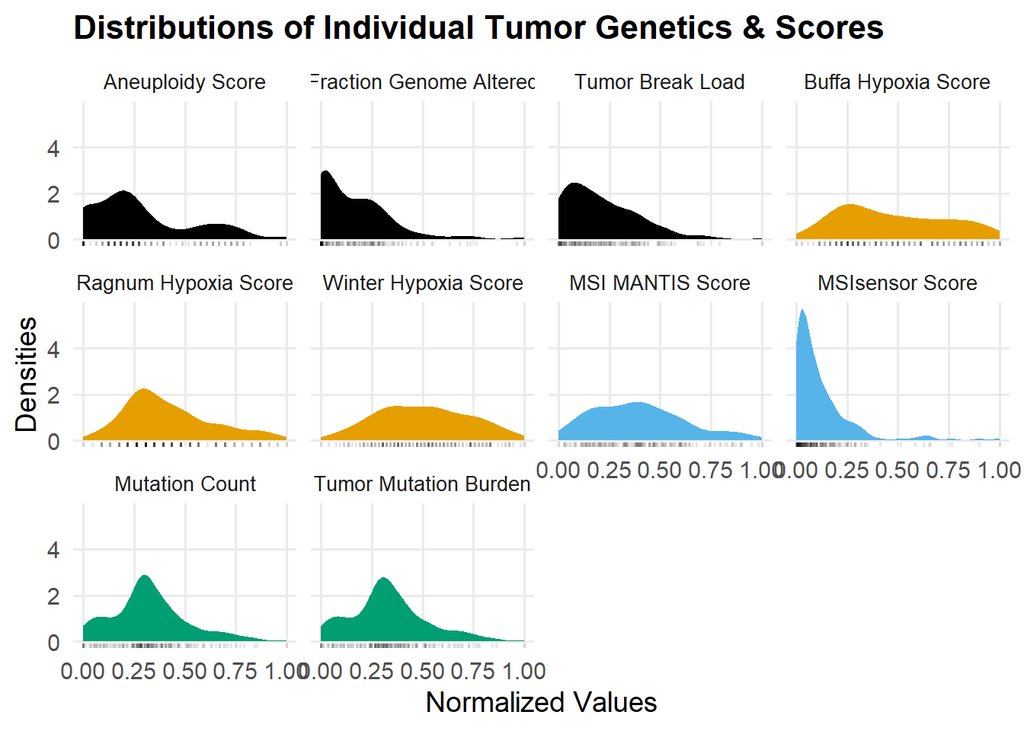

```r
#reorder categories by similarity for the next density plot
combined_norm <- combined_norm |>
  mutate(
    Category = factor(
      Category,
      levels = combined_norm |>
      arrange(Group, Category) |>
      pull(Category) |>
      unique()
    )
  )

#facet wrap density plot for all of the categories
ggplot(combined_norm, aes(x = NormValue)) +
  geom_density(
    aes(fill = Group),
    alpha = 1.0,
    color = NA,
    adjust = 1.0
  ) +
  geom_rug(alpha = 0.1, sides = "b") +
  facet_wrap(~ Category, scales = "fixed") +
  theme_minimal(base_size = 14) +
  labs(
    title = "Distributions of Individual Tumor Genetics & Scores",
    x = "Normalized Values",
    y = "Densities",
    fill = "Group"
  ) +
  scale_fill_manual(
    values = c(
      "#000000", "#E69F00", "#56B4E9", "#009E73",
      "#F0E442", "#0072B2", "#D55E00", "#CC79A7"
    )
  ) +
  theme(
    legend.position = "none",
    plot.title = element_text(face = "bold", size = 16),
    panel.grid.minor = element_blank(),
    strip.text = element_text(size = 10)
  )
```

## Summary of Cancer Codes

Includes both international (ICD) and American (AJCC) code standards. Column plot shows what codes dominate within each classification/category. Heatmap shows absolute co-occurence across all codes.

In our datasets, multiple variables often classify similar attributes or quantify related parameters, so it is essential to analyze the correlations between these variables to uncover their relationships and potential interdependencies.

Furthermore, some variables may not be meaningful for analysis. For example, nominal variables that overwhelmingly dominate the dataset, where one category accounts for the vast majority of observations, may offer limited insight and can be excluded from detailed examination.

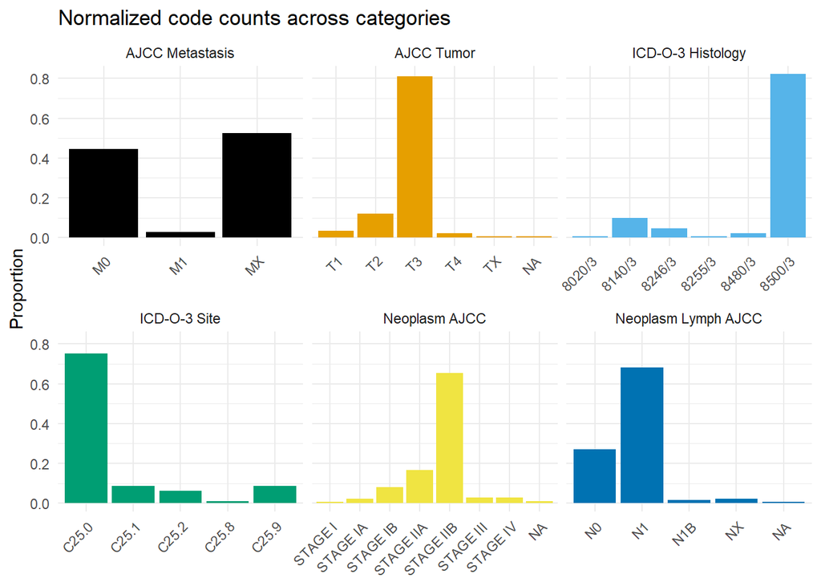

```r
#column plot with normalized code counts
data_code |>
  select(all_of(code_vars)) |>
  pivot_longer(
    cols = everything(),
    names_to="Category",
    values_to="Value"
  )|>
  group_by(Category) |>
  count(Value) |>
  mutate(p = n / sum(n)) |>
  ggplot(aes(Value, p, fill = Category)) +
  geom_col() +
  facet_wrap(~ Category, scales = "free_x") +
  labs(
    title = "Normalized code counts across categories"
  ) +
  scale_fill_manual(values = c(
    "#000000", "#E69F00", "#56B4E9", "#009E73",
    "#F0E442", "#0072B2", "#D55E00", "#CC79A7"
  )
) +
theme_minimal() +
theme(
  axis.text.x = element_text(angle=45, hjust=1),
  axis.title.x = element_blank(),
  legend.position = "none"
) +
ylab("Proportion")
```

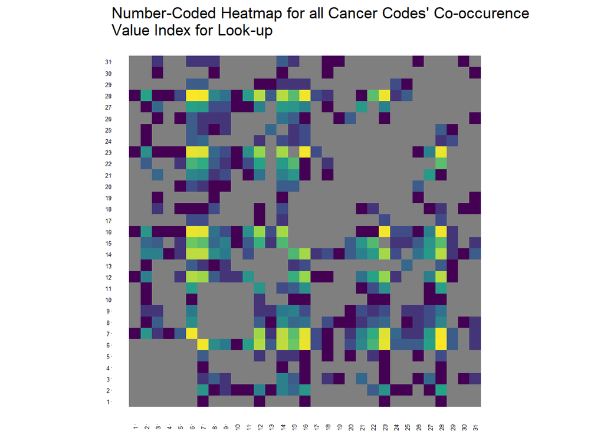

```r
#chessboard heatmap for cross-category codes
df <- data_code |>
  select(all_of(code_vars))

#extract all unique values across all variables
#use this as a key to look up codes in the heatmap
value_index <- df |>
  pivot_longer(
    cols = everything(),
    names_to="Category",
    values_to="Value"
) |>
distinct(Value) |>
arrange(Value) |>
mutate(ID = row_number())

#convert the entire dataframe to df_id form
df_id <- df |>
  mutate(
    across(
      everything(),
      ~ value_index$ID[ match(.x, value_index$Value) ]
    )
  )

#long format for co-occurrence
long <- df_id |>
  mutate(RowID = row_number()) |>
  pivot_longer(
    cols = -RowID,
    names_to="Category",
    values_to="ID"
  )

#compute co-occurrences
pairs <- long |>
  inner_join(long, by="RowID") |>
  filter(ID.x != ID.y) |>
  count(ID.x, ID.y, name="n")
#build matrix
co_matrix <- pairs |>
  pivot_wider(
    names_from = ID.y,
    values_from = n,
    values_fill = 0
  ) |>
  arrange(ID.x)

#plot chessboard heatmap
co_matrix |>
  pivot_longer(
    cols = -ID.x,
    names_to="ID.y",
    values_to="n"
  ) |>
  ggplot(
    aes(
      x = as.integer(ID.x),
      y = as.integer(ID.y),
      fill = n
    )
  ) +
  geom_tile() +
  scale_x_continuous(breaks = 1:max(co_matrix$ID.x)) +   #notice: non-tidyverse
  scale_y_continuous(breaks = 1:max(co_matrix$ID.x)) +   #notice: non-tidyverse
  coord_fixed() +
  labs(
    title = "Number-Coded Heatmap for all Cancer Codes' Co-occurence\nValue Index for Look-up"
  ) +
  scale_fill_viridis_c(
    trans = "log10",
    guide = "none"
  ) +
  theme_void() +
  theme(
    axis.text.x = element_text(angle = 90, vjust = 0.5, size = 5),
    axis.text.y = element_text(size = 5),
    axis.ticks = element_line(size = 0.2),
    plot.margin = margin(0,0,0,0)
  )
```

```r
value_index
```

```
# A tibble: 31 × 2
   Value     ID
   <chr>  <int>
 1 8020/3     1
 2 8140/3     2
 3 8246/3     3
 4 8255/3     4
 5 8480/3     5
 6 8500/3     6
 7 C25.0      7
 8 C25.1      8
 9 C25.2      9
10 C25.8     10
# ℹ 21 more rows
```

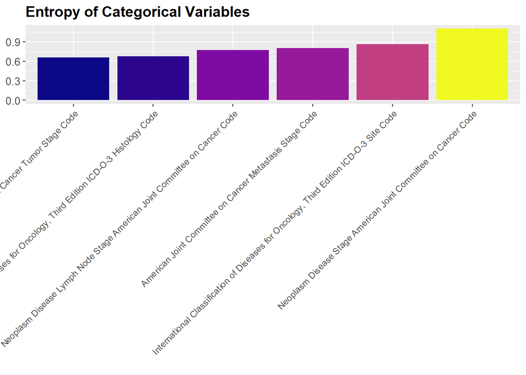

```r
#calculate entropy of top-level codes
entropy_cat <- function(x) {
  p <- prop.table(table(x))
  -sum(p * log(p))
}

data_code |>
  pivot_longer(
    cols = all_of(unname(code_vars)),
    names_to = "var_name",
    values_to = "value"
  ) |>
  group_by(var_name) |>
  summarise(
    entropy = entropy_cat(value[!is.na(value)]),
    n_levels = n_distinct(value, na.rm = TRUE)
  ) |>
  arrange(desc(entropy)) |>
  ggplot(
    aes(
      x = reorder(var_name, entropy),
      y = entropy,
      fill = entropy
    )
  ) +
  geom_col() +
  scale_fill_viridis_c(option = "C") +
  labs(
    title = "Entropy of Categorical Variables",
    x = NULL,
    y = "Entropy"
  ) +
  theme(
    axis.text.x = element_text(angle = 45, hjust = 1),
    axis.title.y = element_blank(),
    axis.text.y = element_text(size = 10),
    legend.position = "none",
    plot.title = element_text(size = 14, face = "bold")
  )
```

## Diagnoses Summary

Summary of the different cancer diagnoses.

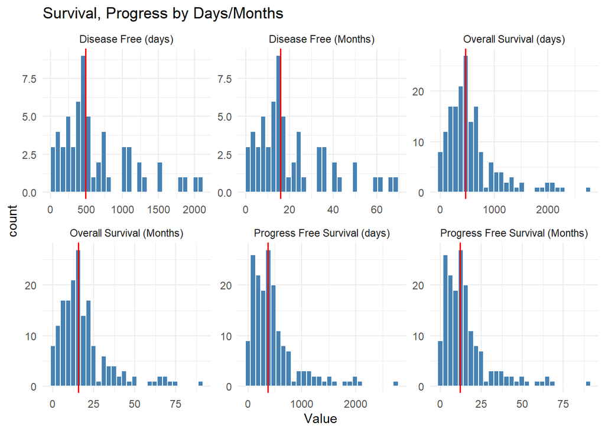

```r
long <- diagnosis_list_numeric |>
  pivot_longer(everything(), names_to = "Variable", values_to = "Value")

medians <- long |>
  group_by(Variable) |>
  summarize(med = median(Value, na.rm = TRUE))

ggplot(long, aes(x = Value)) +
  geom_histogram(bins = 30, fill = "steelblue", color = "white") +
  geom_vline(
    data = medians,
    aes(xintercept = med),
    color = "red", linewidth = 0.7
  ) +
  facet_wrap(~ Variable, scales = "free") +
  labs(
    title = "Survival, Progress by Days/Months") +
  theme_minimal()
```

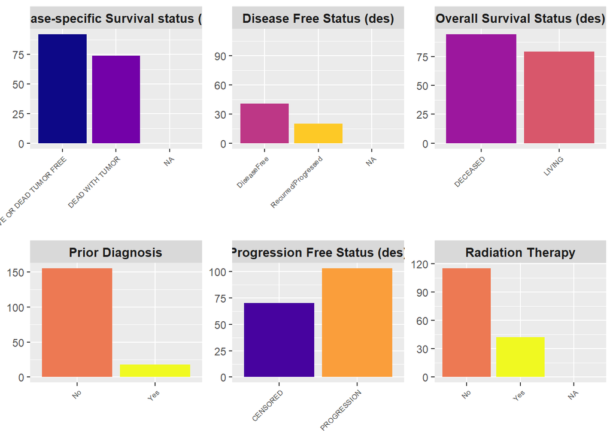

```r
#function to make facet wrap plots
make_facet_plot <- function(data, var_names) {
  data |>
    select(all_of(var_names)) |>
    pivot_longer(everything(), names_to = "Category", values_to = "Value") |>

    #filter out various forms of NAs for clean facet wrap plots
    filter(!Value %in% c("NA", "N/A", "Unknown", "UNK", "Missing", "NONE", "")) |>

    ggplot(aes(x = Value, fill = Value)) +
      geom_bar(na.rm = TRUE) +
      facet_wrap(~ Category, scales = "free") +

      scale_fill_viridis_d(option = "C") +   #for continuous variables

      theme(
        axis.title = element_blank(),        # remove axis titles
        axis.text.x = element_text(angle = 45, hjust = 1, size = 6),
        strip.text = element_text(size = 10, face = "bold"),
        legend.position = "none"             # no legend since categories differ
      )
}

plot_top <- make_facet_plot(data_diag, top_vars)
plot_top
```

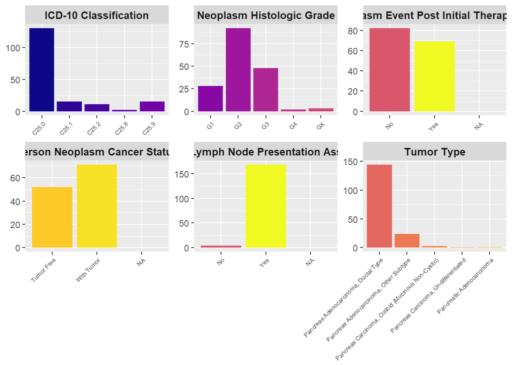

```r
plot_bottom <- make_facet_plot(data_diag, bottom_vars)
plot_bottom
```

## Coding System Comparison From Site Code to Histiology Code to Cancer Code

This plot shows how patients flow across three different categorical systems, revealing how tumor location, pathologic subtype, and disease stage are related. In general, the data is dominated by one histologic type, 8500/3 which is invasive ductal carcinoma. Most of the tumors were taken from C25.0, the pancreatic head region, which can be seen as most patients flow from this section. It can be seen that the main pathway is from C25.0 to 8500/3 to Stage IIB.

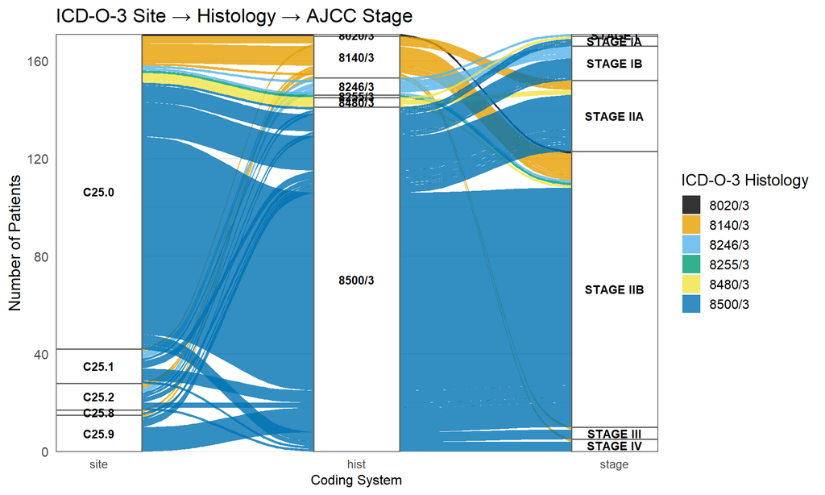

```r
palette <- c(
  "#000000", "#E69F00", "#56B4E9", "#009E73",
  "#F0E442", "#0072B2", "#D55E00", "#CC79A7"
)

#store column names once
cols <- c(
  site     = "International Classification of Diseases for Oncology, Third Edition ICD-O-3 Site Code",
  hist     = "International Classification of Diseases for Oncology, Third Edition ICD-O-3 Histology Code",
  stage    = "Neoplasm Disease Stage American Joint Committee on Cancer Code"
)

data_code |>
  drop_na(all_of(unname(cols))) |>
  count(
    ICD_O3_Site       = .data[[cols["site"]]],
    ICD_O3_Histology  = .data[[cols["hist"]]],
    AJCC_Stage        = .data[[cols["stage"]]]
  ) |>

  ggplot(aes(
    axis1 = ICD_O3_Site,
    axis2 = ICD_O3_Histology,
    axis3 = AJCC_Stage,
    y = n
  )) +

  geom_alluvium(aes(fill = ICD_O3_Histology), alpha = 0.8) +
  geom_stratum(fill = "white", color = "gray40", linewidth = 0.6) +
  geom_text(
    stat = "stratum",
    aes(label = after_stat(stratum)),
    color = "black", fontface = "bold", size = 3.5
  ) +

  scale_fill_manual(values = palette) +
  scale_x_discrete(
    limits = names(cols),
    expand = expansion(mult = 0.02)
  ) +
  scale_y_continuous(expand = c(0, 0)) +

  labs(
    title = "ICD-O-3 Site → Histology → AJCC Stage",
    x = "Coding System",
    y = "Number of Patients",
    fill = "ICD-O-3 Histology"
  ) +

  theme_minimal(base_size = 14) +
  theme(
    axis.title.x   = element_text(size = 12),
    axis.text.x    = element_text(size = 10),
    legend.position = "right"
  )
```

## **Loading libraries**

```r
library("tidyverse")
library("here")
library("broom")
library("corrplot")
```

## Visual Guidelines

```r
theme_uniform <- function(base_size = 14, base_family = "sans") {
  theme_minimal(base_size = base_size, base_family = base_family) +
    theme(
      plot.title    = element_text(face = "bold", size = base_size + 2, hjust = 0),
      axis.title    = element_text(face = "bold"),
      axis.text     = element_text(color = "gray20"),
      panel.grid.minor = element_blank(),
      panel.grid.major = element_line(color = "gray90", size = 0.3),
      strip.text    = element_text(face = "bold"),
      strip.background = element_rect(fill = "gray95", color = NA),
      legend.position = "right",
      legend.title = element_text(face = "bold"),
      plot.margin = margin(10, 10, 10, 10)
    )
}

#colorblind-safe color PALETTE
#pick values for color and fill
palette <- c(
  "#E69F00", "#56B4E9", "#009E73",
  "#F0E442", "#0072B2", "#D55E00", "#CC79A7"
)

#colorblind-safe color GRADIENTS
scale_fill_uniform_continuous  <- scale_fill_gradientn(
  colors = c("#2166AC", "#F7F7F7", "#B2182B")
)
scale_color_uniform_continuous <- scale_color_gradientn(
  colors = c("#2166AC", "#F7F7F7", "#B2182B")
)

#geometry defaults
update_geom_defaults("line",   list(linewidth = 1))
update_geom_defaults("point",  list(size = 2, stroke = 0.5))
update_geom_defaults("boxplot", list(linewidth = 0.6))
update_geom_defaults("violin",  list(linewidth = 0.6))

#presentation settings
presentation_fig_width  <- 7
presentation_fig_height <- 4.5
presentation_dpi        <- 200

#aspect ratios
aspect_wide    <- c(width = 7,  height = 4)   #wide (16:9) for time series / line plots:
aspect_square  <- c(width = 5,  height = 5)   #square (1:1) for correlations & scatter:
aspect_tall    <- c(width = 5,  height = 7)   #tall (3:4) for barplots with long labels:

#annotation settings high contrast
annotation_text <- list(color = "black", size = 5, fontface = "bold")

#remove excess padding
scale_y_continuous_uniform <- scale_y_continuous(expand = expansion(mult = c(0, 0.05)))
scale_x_continuous_uniform <- scale_x_continuous(expand = expansion(mult = c(0.02, 0.02)))
```

## **Loading data**

Loading the data from the previous augmentation step *03_augment*.

```r
data_metrics <- read_tsv(here("data","data_metrics_aug.tsv"))
data_gene <- read_tsv(here("data","data_gene_aug.tsv"))
data_score <- read_tsv(here("data","data_score_aug.tsv"))
data_code <- read_tsv(here("data","data_code_aug.tsv"))
data_diag <- read_tsv(here("data","data_diag_aug.tsv"))
```

- **data_metrics** — patient demographics (age, sex, race, ancestry)
- **data_gene** — genomic instability metrics (mutation count, TMB, fraction genome altered).
- **data_score** — biological scores (aneuploidy, hypoxia, MSI).
- **data_code** — cancer staging and clinical classification codes.
- **data_diag** — diagnoses, survival outcomes, therapy history.

## PCA

We performed PCA to reduce the dimensionality of our clinical and genomic variables and to explore major patterns of variation across patients. We first selected the continuous variables of interest from the merged dataset, then centered and scaled them so they were on comparable scales, and finally ran PCA with `prcomp()` to obtain principal components for visualization and downstream analyses.

```r
data_all <- data_metrics |>
  left_join(data_gene,  by = "Patient ID") |>
  left_join(data_score, by = "Patient ID") |>
  left_join(data_code,  by = "Patient ID") |>
  left_join(data_diag,  by = "Patient ID")
```

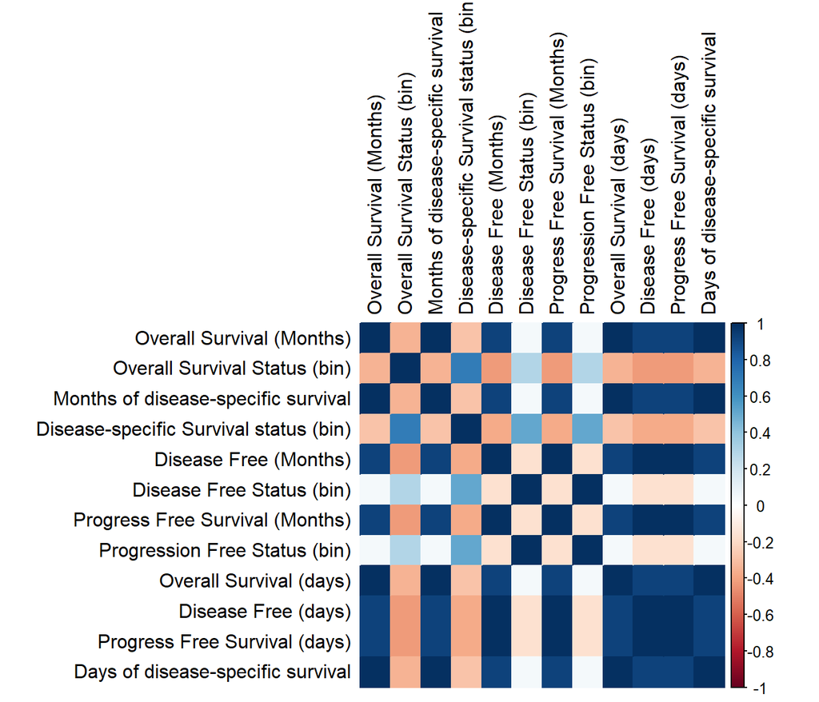

```r
correl_matrix <- data_diag |>
  select(where(is.numeric)) |>
  cor(use = "complete.obs")

corrplot(correl_matrix, method = "color", tl.col = "black")
```

We used the correlation matrix to identify highly redundant diagnostic variables, particularly pairs that measured the same survival outcome in different time units (days vs. months). Based on this, we selected a subset of endpoints that did not show strong mutual correlations to avoid duplication and to keep only non-redundant variables for subsequent analyses.

```r
pca_data <- data_all |>
  select(
    where(is.numeric),
    -c(`Overall Survival (Months)`,
       `Disease Free (Months)`,
       `Months of disease-specific survival`,
       `Progress Free Survival (Months)`,
       `Disease Free Status (bin)`,
       `Disease Free (days)`, # loads of NA because some die
       `Days of disease-specific survival`,
       `Progress Free Survival (days)`
    )
  )  |>
  drop_na()
```

```r
data_pca <- pca_data |>
  drop_na()
```

```r
pca_fit <- data_pca |>
  select(-`Disease-specific Survival status (bin)`) |>
  scale() |>
  prcomp()
```

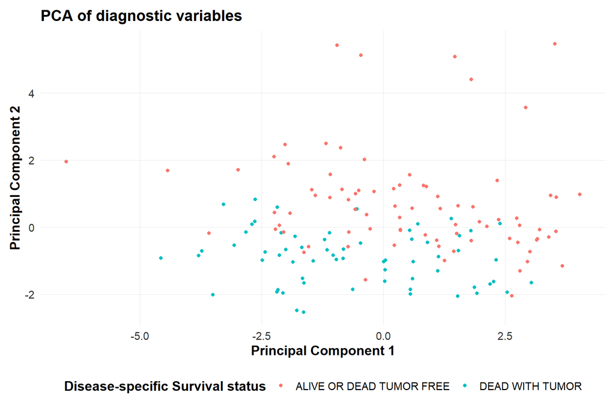

```r
pca_fit |>
  augment(data_pca) |>
  ggplot(aes(x = .fittedPC1,
             y = .fittedPC2,
             color = factor(`Disease-specific Survival status (bin)`))) +
  geom_point(size = 1.5) +
  scale_color_discrete(
    name   = "Disease-specific Survival status",
    labels = c("ALIVE OR DEAD TUMOR FREE", "DEAD WITH TUMOR")  # 0 -> "Alive", 1 -> "Dead"
  ) +
  labs(
    title = "PCA of diagnostic variables",
    x = "Principal Component 1",
    y = "Principal Component 2"
  ) +
  theme_uniform() +
  theme(
    legend.position = "bottom",
    legend.direction = "horizontal"
  )
```

In the PCA plot of the first two components, patients who were dead with tumor and those who were alive or dead tumor‑free occupy partially distinct regions of the PC1–PC2 space, suggesting some degree of separation between the two groups. However, there is substantial overlap between clusters, indicating that the main axes of variation in the selected diagnostic variables only moderately discriminate disease specific survival status.

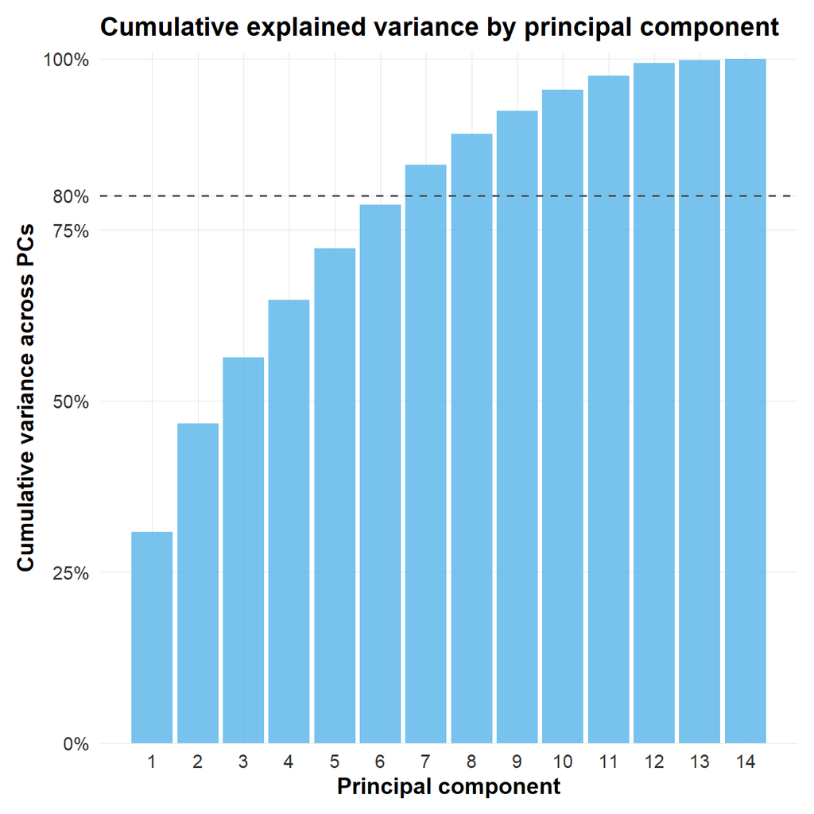

```r
pca_fit |>
  tidy(matrix = "eigenvalues") |>
  ggplot(aes(PC, cumulative)) +
  geom_col(fill = "#56B4E9", alpha = 0.8) +
  geom_hline(yintercept = 0.8,
             linetype = "dashed",
             color = "grey30",
             linewidth = 0.6) +
  scale_x_continuous(breaks = 1:14) +
  scale_y_continuous(
  breaks = c(0, 0.25, 0.5, 0.75, 0.8, 1),
  labels = scales::percent_format(),
  expand = expansion(mult = c(0, 0.01))
) +
  theme_uniform() +
  labs(
  x = "Principal component",
  y = "Cumulative variance across PCs",
  title = "Cumulative explained variance by principal component"
)
```

The cumulative variance plot shows that the first few principal components already explain most of the variability in the diagnostic variables. In our data, the first PC accounts for about one third of the variance, and the first 7-8 PCs together exceed the commonly used 80–90% threshold, indicating that a relatively low-dimensional representation captures the majority of information in the original feature set.

```r
rotation_matrix <- pca_fit |>
  tidy(matrix = "rotation")
```

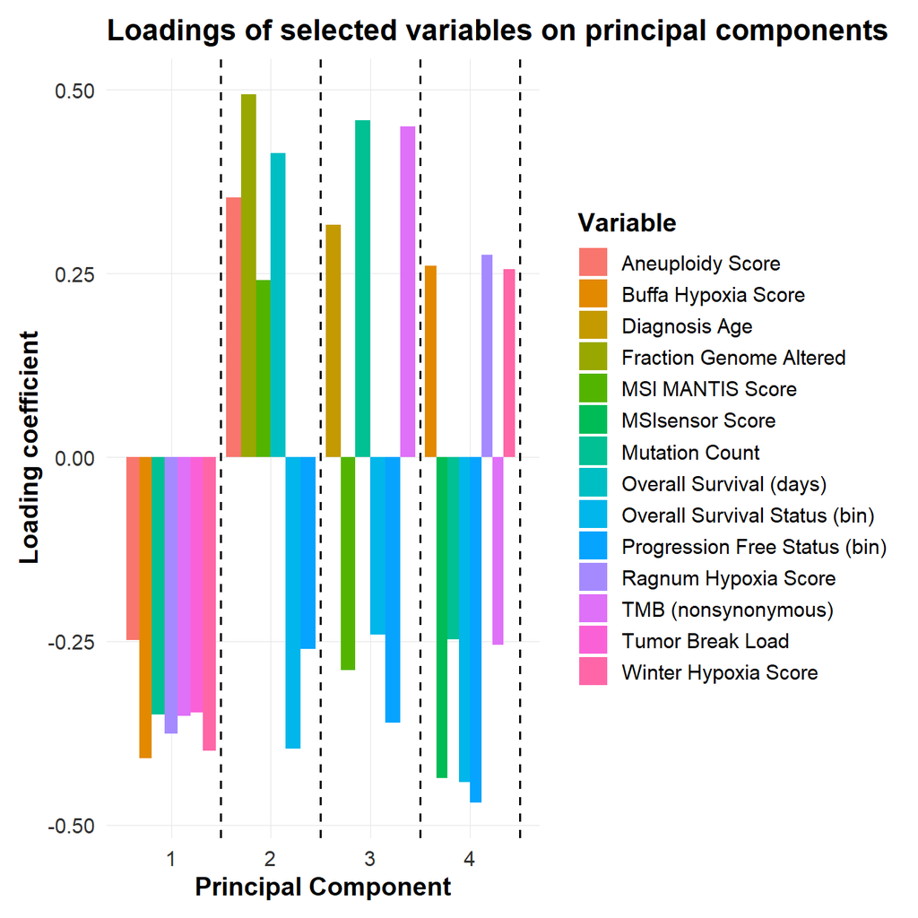

```r
number_of_PC = 4
minimum_value_for_coef = 0.2

rotation_matrix |>
  filter(
    PC %in% c(1:number_of_PC),
    abs(value) > minimum_value_for_coef
  ) |>
  ggplot(aes(x = PC,
             y = value,
             fill = column)) +
  geom_col(position = "dodge") +
  geom_vline(
    xintercept = seq(1.5, length(c(1:number_of_PC)) + 0.5, by = 1),
    linetype = "dashed"
  ) +
  labs(
    title = "Loadings of selected variables on principal components",
    x = "Principal Component",
    y = "Loading coefficient",
    fill = "Variable"
  ) +
  theme_uniform()
```

The loading plot for the first four principal components shows which diagnostic and biological variables contribute most strongly to each PC. PC1 is mainly driven by hypoxia scores and genomic instability metrics, whereas PC2 and PC3 capture additional variation related to survival endpoints and mutation/TMB measures, with opposite signs indicating variables that vary in contrasting directions. Overall, the pattern of loadings suggests that the main PCs summarize combined effects of hypoxia, genomic instability, and survival outcomes rather than being dominated by a single variable.

The PCA of the selected diagnostic and molecular variables provided a compact, low‑dimensional representation that explained most of the variance with only a handful of components. The PCA loadings highlighted clusters of variables with similar contributions to the same components, consistent with the strong correlations observed among several variables, and reinforcing that part of the information in the feature set is redundant.

## **Loading libraries**

```r
library("patchwork")
library("tidyverse")
library("ggplot2")
library("corrplot")
library("here")
library("ggridges")
```

## **Loading data**

Loading the data from the previous augmentation step *03_augment*.

```r
data_metrics <- read_tsv(here("data","data_metrics_aug.tsv"))
data_gene <- read_tsv(here("data","data_gene_aug.tsv"))
data_score <- read_tsv(here("data","data_score_aug.tsv"))
data_code <- read_tsv(here("data","data_code_aug.tsv"))
data_diag <- read_tsv(here("data","data_diag_aug.tsv"))
```

## Visual Guidelines

```r
theme_uniform <- function(base_size = 14, base_family = "sans") {
  theme_minimal(base_size = base_size, base_family = base_family) +
    theme(
      plot.title    = element_text(face = "bold", size = base_size + 2, hjust = 0),
      axis.title    = element_text(face = "bold"),
      axis.text     = element_text(color = "gray20"),
      panel.grid.minor = element_blank(),
      panel.grid.major = element_line(color = "gray90", size = 0.3),
      strip.text    = element_text(face = "bold"),
      strip.background = element_rect(fill = "gray95", color = NA),
      legend.position = "right",
      legend.title = element_text(face = "bold"),
      plot.margin = margin(10, 10, 10, 10)
    )
}

#colorblind-safe color PALETTE
#pick values for color and fill
palette <- c(
  "#E69F00", "#56B4E9", "#009E73",
  "#F0E442", "#0072B2", "#D55E00", "#CC79A7"
)

#colorblind-safe color GRADIENTS
scale_fill_uniform_continuous  <- scale_fill_gradientn(
  colors = c("#2166AC", "#F7F7F7", "#B2182B")
)
scale_color_uniform_continuous <- scale_color_gradientn(
  colors = c("#2166AC", "#F7F7F7", "#B2182B")
)

#geometry defaults
update_geom_defaults("line",   list(linewidth = 1))
update_geom_defaults("point",  list(size = 2, stroke = 0.5))
update_geom_defaults("boxplot", list(linewidth = 0.6))
update_geom_defaults("violin",  list(linewidth = 0.6))

#presentation settings
presentation_fig_width  <- 7
presentation_fig_height <- 4.5
presentation_dpi        <- 200

#aspect ratios
aspect_wide    <- c(width = 7,  height = 4)   #wide (16:9) for time series / line plots:
aspect_square  <- c(width = 5,  height = 5)   #square (1:1) for correlations & scatter:
aspect_tall    <- c(width = 5,  height = 7)   #tall (3:4) for barplots with long labels:

#annotation settings high contrast
annotation_text <- list(color = "black", size = 5, fontface = "bold")

#remove excess padding
scale_y_continuous_uniform <- scale_y_continuous(expand = expansion(mult = c(0, 0.05)))
scale_x_continuous_uniform <- scale_x_continuous(expand = expansion(mult = c(0.02, 0.02)))
```

## Data Description/ Notes for Analysis

Summary of the data:

- **data_metrics** — patient demographics (age, sex, race, ancestry)
- **data_gene** — genomic instability metrics (mutation count, TMB, fraction genome altered).
- **data_score** — biological scores (aneuploidy, hypoxia, MSI).
- **data_code** — cancer staging and clinical classification codes.
- **data_diag** — diagnoses, survival outcomes, therapy history.

## Genomic Alterations & Instability Analysis (**data_gene)**

### Relationship between continuous genomic instability measures and overall survival (days)

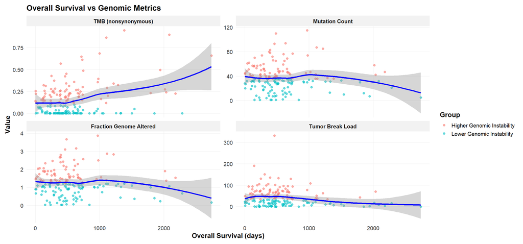

```r
# Joining tables and filter out outliers
data_gene_diag <- full_join(data_gene, data_diag, by = "Patient ID")

# Reshape to Long Dataset
data_long <- data_gene_diag |>
  mutate(
    TMB = `TMB (nonsynonymous)`,
    MutCount = `Mutation Count`,
    FracGenome = `Fraction Genome Altered`,
    TumorLoad = `Tumor Break Load`
  ) |>
  pivot_longer(
    cols = c(TMB, MutCount, FracGenome, TumorLoad),
    names_to = "Metric",
    values_to = "Value"
  )

# Compute medians per metric
medians <- data_long |>
  group_by(Metric) |>
  summarize(med = median(Value, na.rm = TRUE))

data_long <- data_long |>
  left_join(medians, by = "Metric") |>
  mutate(
    Group = case_when(
      Value > med ~ "Higher Genomic Instability",
      Value <= med ~ "Lower Genomic Instability"
      ),
    Metric = factor(
      Metric,
      labels = c(
        "TMB (nonsynonymous)",
        "Mutation Count",
        "Fraction Genome Altered",
        "Tumor Break Load"
      )))

## PLOTTING
# Scatter/LOESS Plot
plt_scatter <- ggplot(
  data_long,
  aes(x = `Overall Survival (days)`,
      y = Value,
      color = Group)
) +
  geom_point(alpha = 0.6) +
  geom_smooth(method = "loess", color = "blue") +
  facet_wrap(~ Metric, scales = "free_y") +
  theme_uniform() +
  labs(title = "Overall Survival vs Genomic Metrics")

# Present Plots
plt_scatter
```

### **Tumor types and Genomic differences across them (not meaningful for further analysis)**

- **Context**: This section compares genomic instability metrics (Mutation Count, TMB, Fraction Genome Altered, Tumor Break Load) across different tumor types, to determine the existance of big difference between them.
- **Analysis from Plots**: The ‘Ductal Adenocarcinoma’ appears to have lower fraction of the genome altered and a slight higher tumor break load compared to others subtypes, altough the differences are very discrete. The other tumor types were discarded due to lack of data.

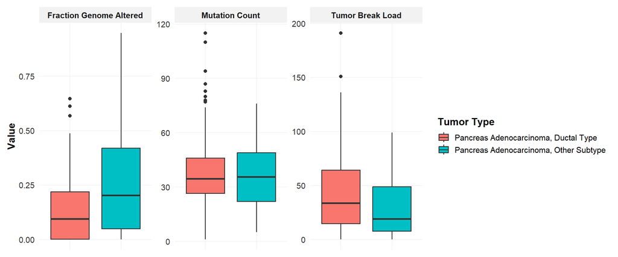

```r
data_gene_diag |>
  filter(
    `Tumor Type` %in% c(
      "Pancreas Adenocarcinoma, Ductal Type",
      "Pancreas Adenocarcinoma, Other Subtype"
    )
  ) |>
  pivot_longer(
    cols = c(
      `Mutation Count`,
      `Fraction Genome Altered`,
      `Tumor Break Load`
    ),
    names_to = "Metric",
    values_to = "Value"
  ) |>
  ggplot(aes(x = `Tumor Type`, y = Value, fill = `Tumor Type`)) +
  geom_boxplot() +
  facet_wrap(~ Metric, nrow = 1, scales = "free_y") +
  theme_uniform() +
  theme(
    axis.title.x = element_blank(),
    axis.text.x  = element_blank(),
    axis.ticks.x = element_blank()
  )
```

### Distribution of Cancer Stages and Genomic Instability

- **Context**: Cancer stage reflects the extent of tumor progression, while genomic instability measures (Mutation Count, Fraction Genome Altered, and Tumor Break Load) capture different aspects of chromosomal and genetic instability. These features are often associated with tumor aggressiveness and poor prognosis. This set of plots explores how cancer stage distributions relate to genomic instability across pancreatic adenocarcinoma subtypes (Ductal Type vs Other Subtypes).
- The stage distribution plot in describe shows a concentration of patients in **Stage IIB**, indicating the dataset is heavily skewed toward mid-stage disease.

```r
data_gene_code = full_join(data_gene, data_code, by = "Patient ID")
```

```r
# 1) Find stages with > 10 samples
stages_keep <- data_gene_code |>
  rename(NDSA_stage = `Neoplasm Disease Stage American Joint Committee on Cancer Code`) |>
  count(NDSA_stage, name = "n_samples") |>
  filter(n_samples > 10)

# 2) Labels
stage_labels <- stages_keep |>
  mutate(stage_label = paste0(NDSA_stage, " (n=", n_samples, ")")) |>
  select(NDSA_stage, stage_label)

# 2) Keep full data only for those stages
data_gene_code_filtered <- data_gene_code |>
  rename(NDSA_stage = `Neoplasm Disease Stage American Joint Committee on Cancer Code`) |>
  filter(!is.na(NDSA_stage)) |>
  semi_join(stages_keep, by = "NDSA_stage")
```

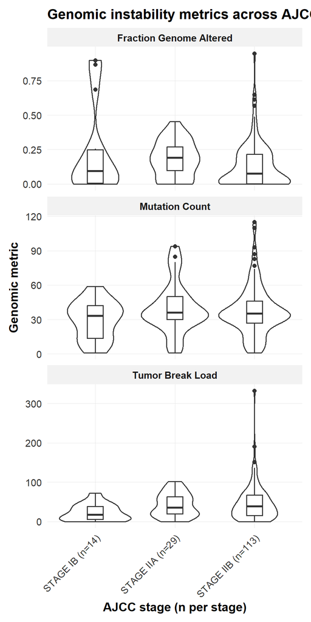

```r
data_gene_code_filtered |>
  left_join(stage_labels, by = "NDSA_stage") |>
  pivot_longer(
    cols = c(
      `Fraction Genome Altered`,
      `Mutation Count`,
      `Tumor Break Load`
    ),
    names_to = "Genomic_Metric",
    values_to = "Value"
  ) |>
  ggplot(aes(x = stage_label, y = Value)) +
  geom_violin() +
  geom_boxplot(width = 0.2) +
  facet_wrap(~ Genomic_Metric,
             scales = "free_y",
             ncol = 1) +
  theme_uniform() +
  theme(axis.text.x = element_text(angle = 45,
                                   hjust = 1)) +
  labs(
    x = "AJCC stage (n per stage)",
    y = "Genomic metric",
    title = "Genomic instability metrics across AJCC stages")
```

To begin, we only included tumor classes with at least 10 patients per AJCC stage, as smaller groups would not provide a reliable representation of the underlying distribution.

- There’s considerable overlap between neighboring stages, so stage alone doesn’t perfectly separate genomic burden.
- One could say that Tumor Break Load tends to increase with tumor stage, as indicated by higher medians and a wider spread of values in the boxplots for advanced stages.
- **TBL measures:** it is the sum of unbalanced structural-variant breakpoints, a quantitative readout of **Structural Variants driven chromosomal instability**.
- So, *in theory*, as tumors accumulate Structural Variants and copy‑number chaos over time, **TBL should rise**, and high TBL is often seen in more aggressive, later‑stage or poorer‑prognosis disease.

### Heatmap of the pairwise correlations between genomic instability and hypoxia-related metrics

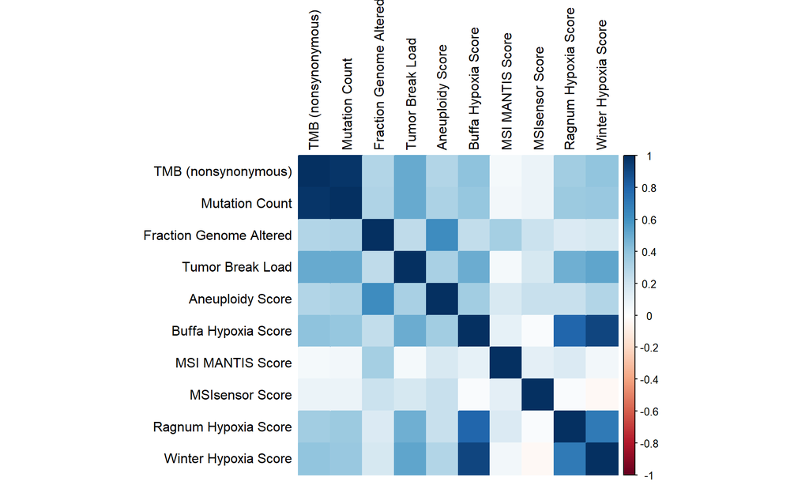

```r
data_full <- data_gene |>
  full_join(data_score, by = "Patient ID") |>
  full_join(data_diag, by = "Patient ID") |>
  full_join(data_metrics, by = "Patient ID")

# Select  columns of interest
cols_to_compare <- c("TMB (nonsynonymous)", "Mutation Count",
                     "Fraction Genome Altered", "Tumor Break Load",
                     "Aneuploidy Score", "Buffa Hypoxia Score",
                     "MSI MANTIS Score", "MSIsensor Score",
                     "Ragnum Hypoxia Score", "Winter Hypoxia Score")

data_numeric <- data_full |>
  select(all_of(cols_to_compare))

correl_matrix <- cor(data_numeric |>
                    select(cols_to_compare),
                    use = "complete.obs")
corrplot(correl_matrix, method = "color",tl.col = "black")
```

This plot was used to assess relationships between genomic instability metrics and hypoxia scores. Focusing on the first four columns (genomic instability measures) and the last six rows (hypoxia scores), no strong blue stand out, indicating that hypoxia scores are not strongly correlated with the genomic instability variables in this dataset.

## Biological scores Analysis (data_score)

### Distribution of Aneuploidy Scores across different Cancer Stages

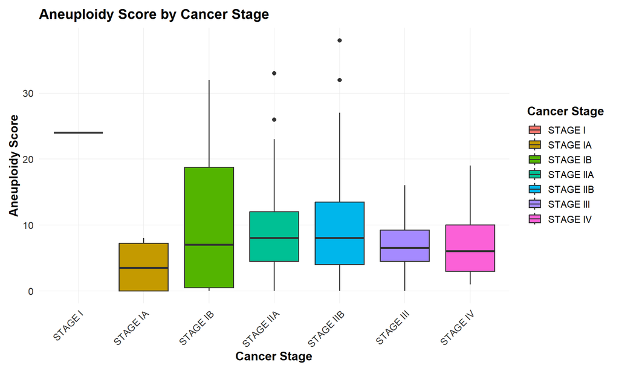

```r
# Relate Cancer Stage with Aneuploidy Score
plt_aneuploidy_stage <- data_code |>
  full_join(data_score, by = "Patient ID") |>
  rename(`Cancer Stage` = `Neoplasm Disease Stage American Joint Committee on Cancer Code`) |>
  drop_na("Cancer Stage") |>
  ggplot(aes(x = `Cancer Stage`,
             y = `Aneuploidy Score`,
             fill = `Cancer Stage`)) +
  geom_boxplot() +
  theme_minimal() +
  theme(
    legend.position = "none",
    plot.title = element_text(hjust = 0.5, face = "bold")
  ) +
  ggtitle("Aneuploidy Score by Cancer Stage") +
  theme_uniform() +
  theme(axis.text.x = element_text(angle = 45, hjust = 1))

plt_aneuploidy_stage
```

The Aneuploidy Score, which quantifies chromosomal instability and is often linked to tumor aggressiveness and poor prognosis, was analyzed to assess whether higher cancer stages correspond to increased chromosomal abnormalities. The plot shows no clear increase in Aneuploidy Score with advancing stage, which may reflect the limited stage diversity in the dataset, particularly the small number of Stage I cases.

### MSI and Hypoxia congruency

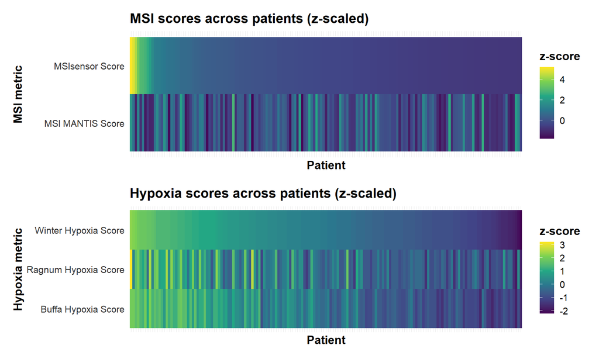

```r
metric_for_order_msi     <- "MSIsensor Score"
metric_for_order_hypoxia <- "Winter Hypoxia Score"

# Long + scaled (as before)
df_long <- data_score |>
  select(`Patient ID`,
         `MSI MANTIS Score`,
         `MSIsensor Score`,
         `Buffa Hypoxia Score`,
         `Ragnum Hypoxia Score`,
         `Winter Hypoxia Score`) |>
  drop_na() |>
  pivot_longer(
    cols = -`Patient ID`,
    names_to = "Metric",
    values_to = "Score"
  ) |>
  group_by(Metric) |>
  mutate(
    Score_scaled = (Score - mean(Score, na.rm = TRUE)) /
                   sd(Score, na.rm = TRUE)
  ) |>
  ungroup()

# MSI: order by MSI metric
df_msi <- df_long |>
  filter(Metric %in% c("MSI MANTIS Score", "MSIsensor Score")) |>
  group_by(`Patient ID`) |>
  mutate(
    order_value = Score_scaled[Metric == metric_for_order_msi][1]
  ) |>
  ungroup() |>
  mutate(
    `Patient ID` = fct_reorder(`Patient ID`, order_value, .desc = TRUE)
  )

# Hypoxia: order by Winter hypoxia
df_hypoxia <- df_long |>
  filter(Metric %in% c("Buffa Hypoxia Score",
                       "Ragnum Hypoxia Score",
                       "Winter Hypoxia Score")) |>
  group_by(`Patient ID`) |>
  mutate(
    order_value = Score_scaled[Metric == metric_for_order_hypoxia][1]
  ) |>
  ungroup() |>
  mutate(
    `Patient ID` = fct_reorder(`Patient ID`, order_value, .desc = TRUE)
  )

MSI_heatmap <- ggplot(df_msi,
       aes(x = `Patient ID`, y = Metric, fill = Score_scaled)) +
  geom_tile() +
  scale_fill_viridis_c() +
  theme_uniform() +
  theme(axis.text.x = element_blank(),
        axis.ticks.x = element_blank()) +
  labs(
    title = "MSI scores across patients (z-scaled)",
    x = "Patient", y = "MSI metric", fill = "z-score"
  )

hypoxia_heatmap <- ggplot(df_hypoxia,
       aes(x = `Patient ID`, y = Metric, fill = Score_scaled)) +
  geom_tile() +
  scale_fill_viridis_c() +
  theme_uniform() +
  theme(axis.text.x = element_blank(),
        axis.ticks.x = element_blank()) +
  labs(
    title = "Hypoxia scores across patients (z-scaled)",
    x = "Patient", y = "Hypoxia metric", fill = "z-score"
  )

MSI_heatmap / hypoxia_heatmap
```

These heatmaps show how MSI and hypoxia scores vary across patients after z‑scaling. In the MSI panel, most patients cluster around low MSI values with only a minority showing high MSI z‑scores, consistent with MSI‑high tumors being relatively rare. In contrast, the hypoxia panel displays a broader spread and more gradual gradients across patients, suggesting greater heterogeneity in hypoxia signatures than in MSI status.

These heatmaps indicate poor agreement between the different hypoxia and MSI scoring methods at the individual-patient level. Apart from Buffa and Winter, which show relatively similar patterns, the remaining signatures often assign very different relative scores to the same patients, suggesting that the choice of scoring method can substantially change which tumors are labeled as hypoxic or MSI-high and that these methods are not interchangeable.

### Score Distribution Along Neoplasm Histological Grades Divided by Cancer Status

For the Buffia Hypoxia Scores, both statuses had increasing trends as Grades went up, with those who had tumors having generally larger scores. For the MSI Mantis Scores, there didn’t seem to be a particular trend for those who did not have tumors. But for those who had a tumor, there was a decreasing trend as Grades went up. For the MSI Sensor Scores, those who did not have tumors had a slight increasing trend as Grades went up, while those who had tumors did not seem to follow a trend. Lastly, for Ragnum Hypoxia Scores, both those who had tumors and who did not have tumors had an increasing trend as Grades went up. Other than G1, those who had tumors had higher scores than those who did not.

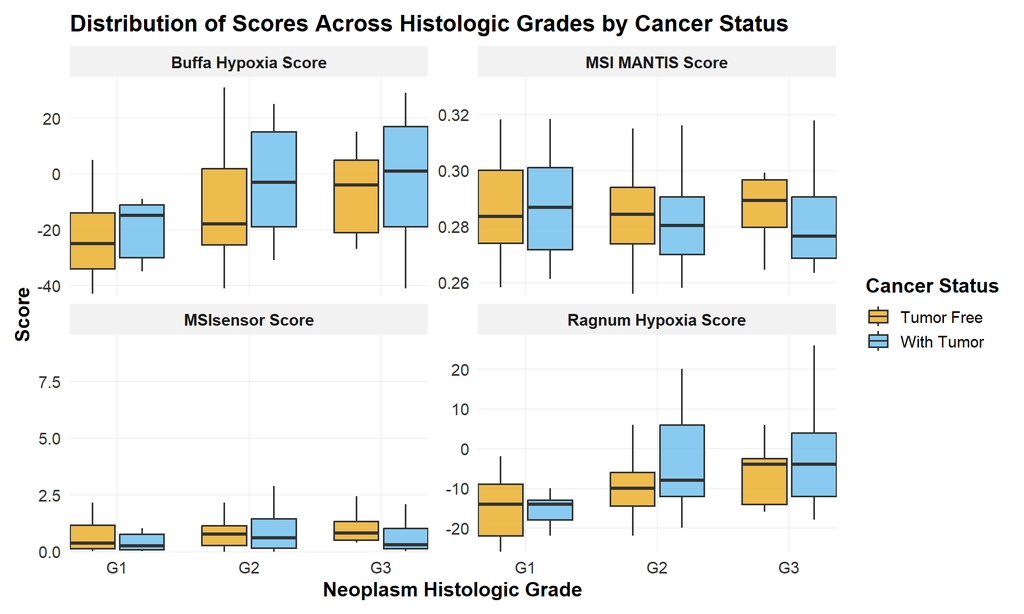

```r
data_score |>
  left_join(data_diag |>
  select(`Patient ID`,
    `Neoplasm Histologic Grade`,
    `Person Neoplasm Cancer Status`),
    by = "Patient ID") |>
  filter(!is.na(`Neoplasm Histologic Grade`),
    !`Neoplasm Histologic Grade` %in% c("GX", "G4")) |>
  pivot_longer(cols = c(`Buffa Hypoxia Score`,
    `Ragnum Hypoxia Score`,
    `MSI MANTIS Score`,
    `MSIsensor Score`),
    names_to  = "Metric",
    values_to = "Score") |>
  filter(!is.na(Score),
    !is.na(`Neoplasm Histologic Grade`),
    !is.na(`Person Neoplasm Cancer Status`)) |>
  ggplot(aes(x = `Neoplasm Histologic Grade`,
    y = Score,
    fill = `Person Neoplasm Cancer Status`)) +
  geom_boxplot(alpha = 0.7,
    outlier.shape = NA) +
  facet_wrap(~ Metric,
    scales = "free_y") +
  scale_fill_manual(values = palette) +
  scale_y_continuous_uniform +
  scale_x_discrete(expand = expansion(mult = c(0.02, 0.02))) +
  labs(title = "Distribution of Scores Across Histologic Grades by Cancer Status",
    x = "Neoplasm Histologic Grade",
    y = "Score",
    fill  = "Cancer Status") +
  theme_uniform()
```

## Diagnostic, Survival (data_diag)

### Patient Survival Comparison with Radiation Therapy and Prior Diagnosis

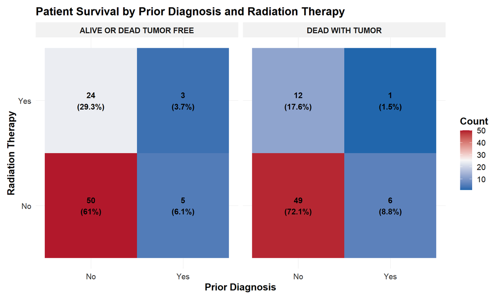

```r
data_diag |>
  drop_na(`Prior Diagnosis`,
    `Disease-specific Survival status (des)`,
    `Radiation Therapy`) |>
  count(Prior_Diagnosis = `Prior Diagnosis`,
    Radiation_Therapy = `Radiation Therapy`,
    Survival = `Disease-specific Survival status (des)`) |>
  group_by(Survival) |>
  mutate(percentage = n / sum(n) * 100) |>
  ggplot(aes(x = Prior_Diagnosis,
    y = Radiation_Therapy,
    fill = n)) +
  geom_tile() +
  geom_text(aes(label = paste0(n,
    "\n(",
    round(percentage,
    1), "%)")),
    color = "black",
    size  = 4,
    fontface = "bold") +
  facet_wrap(~ Survival) +
  scale_fill_uniform_continuous +
  labs(title = "Patient Survival by Prior Diagnosis and Radiation Therapy",
    x  = "Prior Diagnosis",
    y = "Radiation Therapy",
    fill = "Count") +
  theme_uniform()
```

It can be seen that for those who had neither a prior diagnosis or radiation therapy and for those who did not have radiation therapy but did have a prior diagnosis, there was a nearly 50-50 split on their survival status. However, for those that did have radiation therapy but did not have a prior diagnosis, there was a near 70-30 split on survival status. Due to the small number of patients who did not fit into the category of no radiation therapy and no prior diagnosis, these numbers may not necessarily be trustworthy. However, in general, this does follow the trend we would expect to see, where those who were not previously sick and who did go through with the therapy would be more likely to survive. It is interesting to see that prior diagnosis status did not seem to show much of an impact on survival status.

### Age Density Between Sexes Across Neoplasm Histologic Grades

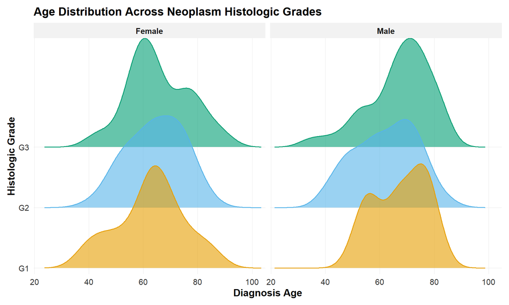

```r
bind_cols(data_metrics |>
  select(Age = `Diagnosis Age`,
    Sex),
    data_diag |>
  select(Neo_Grade = `Neoplasm Histologic Grade`)) |>
  filter(!Neo_Grade %in% c("GX",
    "G4")) |>
  ggplot(aes(x = Age,
    y = Neo_Grade,
    fill = Neo_Grade,
    color = Neo_Grade)) +
  geom_density_ridges(alpha = 0.6,
    linewidth = 0.6) +
  facet_wrap(~ Sex) +
  scale_fill_manual(values = palette) +
  scale_color_manual(values = palette) +
  scale_x_continuous_uniform +
  scale_y_discrete(expand = expansion(mult = c(0.05,
    0.05))) +
  labs(title = "Age Distribution Across Neoplasm Histologic Grades",
    x = "Diagnosis Age",
    y = "Histologic Grade",
    fill = "Grade") +
  theme_uniform() +
  theme(legend.position = "none")
```

GX was removed due to there being only 3 instances of it and also that it represents an inability to properly assign a grade. G4 was removed due to there being only 2 instances and therefore not being able to show statistically significant data.

## **Loading libraries**

```r
library("patchwork")
library("tidyverse")
library("here")
```

## **Loading data**

Loading the data from the previous augmentation step *03_augment*.

```r
data_metrics <- read_tsv(here("data","data_metrics_aug.tsv"))
data_gene <- read_tsv(here("data","data_gene_aug.tsv"))
data_score <- read_tsv(here("data","data_score_aug.tsv"))
data_code <- read_tsv(here("data","data_code_aug.tsv"))
data_diag <- read_tsv(here("data","data_diag_aug.tsv"))
```

## **Plotting data**

#### Relationship between genomic instability measures and status with tumor/ tumor free

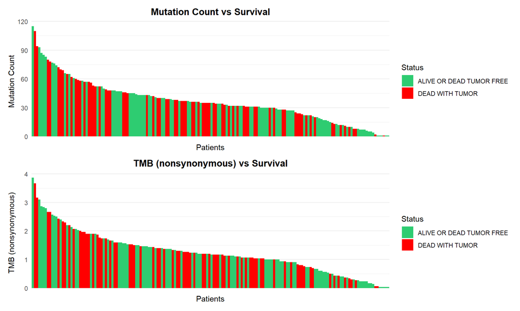

```r
# Preparing the data
data_full <- data_gene |>
  full_join(data_diag, by = "Patient ID") |>
  drop_na(`Disease-specific Survival status (des)`) |>
  mutate(Status = `Disease-specific Survival status (des)`)

#  Colors to separate cancer status
status_colors <- c(
  "DEAD WITH TUMOR" = "red",
  "ALIVE OR DEAD TUMOR FREE" = "#2ECC71"
)

## Plotting
# Plot - Mutation Count
plt_mut_count <- data_full |>
  arrange(desc(`Mutation Count`)) |>
  mutate(Patient_Order = factor(`Patient ID`,
                                levels = `Patient ID`))|>
  ggplot(aes(x = Patient_Order,
             y = `Mutation Count`,
             fill = Status)) +
  geom_col(width = 1) +
  scale_fill_manual(values = status_colors) +
  theme_minimal() +
  theme(axis.text.x = element_blank(),
        axis.ticks.x = element_blank(),
        panel.grid.major.x = element_blank(),
        plot.title = element_text(hjust = 0.5, face = "bold")) +
  labs(title = "Mutation Count vs Survival",
       x = "Patients",
       y = "Mutation Count")


# Plot - Tumor Break Load
plt_tbl <- data_full |>
  arrange(desc(`Tumor Break Load`)) |>
  mutate(Patient_Order = factor(`Patient ID`,
                                levels = `Patient ID`))|>
  ggplot(aes(x = Patient_Order,
             y = `Tumor Break Load`,
             fill = Status)) +
  geom_col(width = 1) +
  scale_fill_manual(values = status_colors) +
  theme_minimal() +
  theme(axis.text.x = element_blank(),
        axis.ticks.x = element_blank(),
        panel.grid.major.x = element_blank(),
        plot.title = element_text(hjust = 0.5, face = "bold")) +
  labs(title = "Tumor Break Load vs Survival",
       x = "Patients",
       y = "Tumor Break Load")


# Plot - TMB (nonsynonymous)
plt_tmb <- data_full |>
  arrange(desc(`TMB (nonsynonymous)`)) |>
  mutate(Patient_Order = factor(`Patient ID`,
                                levels = `Patient ID`)) |>
  ggplot(aes(x = Patient_Order,
             y = `TMB (nonsynonymous)`,
             fill = Status)) +
  geom_col(width = 1) +
  scale_fill_manual(values = status_colors) +
  theme_minimal() +
  theme(axis.text.x = element_blank(),
        axis.ticks.x = element_blank(),
        panel.grid.major.x = element_blank(),
        plot.title = element_text(hjust = 0.5, face = "bold")) +
  labs(title = "TMB (nonsynonymous) vs Survival",
       x = "Patients",
       y = "TMB (nonsynonymous)")


# Fraction Genome Altered (FGA) - Plot
plt_fga <- data_full |>
  arrange(desc(`Fraction Genome Altered`)) |>
  mutate(Patient_Order = factor(`Patient ID`,
                                levels = `Patient ID`))|>
  ggplot(aes(x = Patient_Order,
             y = `Fraction Genome Altered`,
             fill = Status)) +
  geom_col(width = 1) +
  scale_fill_manual(values = status_colors) +
  theme_minimal() +
  theme(axis.text.x = element_blank(),
        axis.ticks.x = element_blank(),
        panel.grid.major.x = element_blank(),
        plot.title = element_text(hjust = 0.5, face = "bold")) +
  labs(title = "Fraction Genome Altered vs Survival",
       x = "Patients",
       y = "Fraction Genome Altered")


# Combine plots
(plt_mut_count / plt_tmb)
```

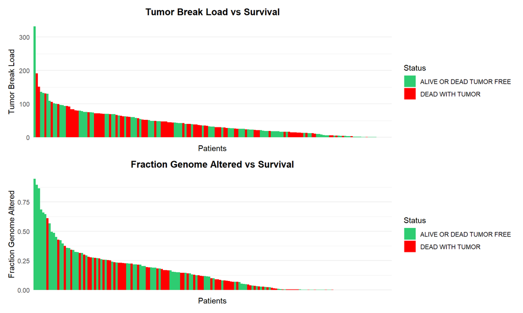

```r
(plt_tbl / plt_fga)
```

```r
# Note: Cannot use facet_wrap because the order of the patients changes
```

No significant correlation was observed between high values of genomic instability (Mutation Count, TMB-nonsynonymous, Tumor Break Load) and the patient status (dead with tumor or alive/death tumor-free).

Surprisingly, a higher fraction of the genome altered was associated with the alive/death tumor-free status. One possible explanation is that this extensive genomic alteration may be a consequence of high-intensity therapy that effectively eradicated the tumor, leading to the tumor-free outcome. However, this specific plot does not allow for direct conclusions regarding this hypothesis.

#### TMB Comparison With Months of Survival Across Survival Status

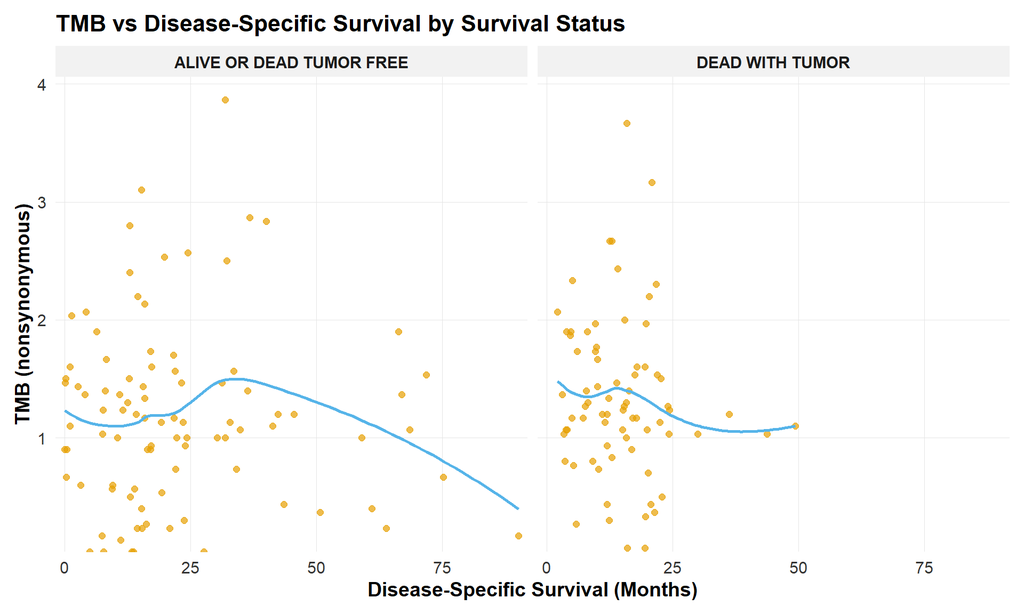

```r
bind_cols(data_diag |>
  select(Months_Disease = `Months of disease-specific survival`,
    Survival_Status = `Disease-specific Survival status (des)`),
    data_gene |>
  select(TMB = `TMB (nonsynonymous)`)) |>
  filter(TMB < 10) |>
  drop_na(Survival_Status) |>
  ggplot(aes(x = Months_Disease,
    y = TMB)) +
  geom_point(alpha = 0.7,
    color = palette[1]) +
  geom_smooth(method = "loess",
    se = FALSE,
    color = palette[2],
    linewidth = 1) +
  facet_wrap(~ Survival_Status) +
  scale_x_continuous_uniform +
  scale_y_continuous_uniform +
  labs(title = "TMB vs Disease-Specific Survival by Survival Status",
    x = "Disease-Specific Survival (Months)",
    y = "TMB (nonsynonymous)") +
  theme_uniform()
```

This plot shows that for both those who became tumor free and those who died from the tumor, a similar trend was followed where, in general, a higher TMB meant fewer months of survival. The trend was mainly differentiated in that there were more months survived for those who became tumor free. This follows the general trend that we would expect to see. However, it is interesting to note that in those who died with a tumor, there was a hump in the slope before 12.5 months, showing that there was diversity in the TMB. After those initial months, there was a negative slope, showing that those that survived longer tended to have lower TMB. For those who did not have a tumor, there was a slight positive slope before 30 months and then a negative slope afterwards.

#### Interaction between Hypoxia and Tumor Break Load, and its effects in Overall Survival (Days)

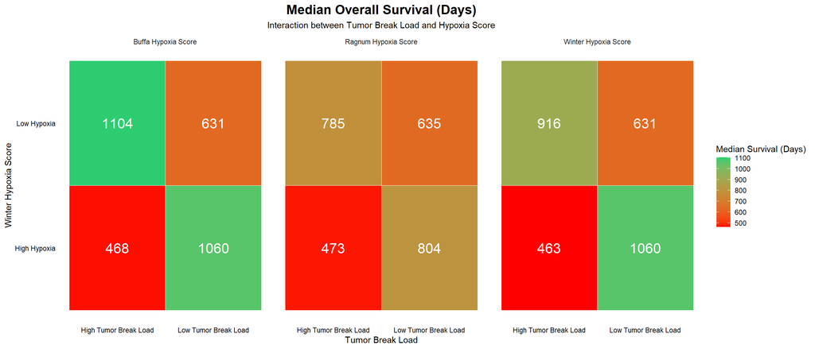

```r
# Prepare data
data_heatmap <- data_gene |>
  full_join(data_diag, by = "Patient ID") |>
  full_join(data_score, by = "Patient ID") |>
  drop_na() |>
  # Pivot hypoxia scores long
  pivot_longer(
    cols = c(`Winter Hypoxia Score`,
             `Buffa Hypoxia Score`,
             `Ragnum Hypoxia Score`),
    names_to = "Hypoxia_Score_Type",
    values_to = "Hypoxia_Value"
  ) |>
  mutate(
    Mut_Count_Bin = case_when(
      `Tumor Break Load` > median(`Tumor Break Load`, na.rm = TRUE) ~ "High Tumor Break Load",
      `Tumor Break Load` <= median(`Tumor Break Load`, na.rm = TRUE) ~ "Low Tumor Break Load")) |>
  group_by(Hypoxia_Score_Type) |>
  mutate(
    Hypoxia_Bin = case_when(
      Hypoxia_Value > median(Hypoxia_Value, na.rm = TRUE) ~ "High Hypoxia",
      Hypoxia_Value <= median(Hypoxia_Value, na.rm = TRUE) ~ "Low Hypoxia"))|>
  ungroup()|>
  group_by(Hypoxia_Score_Type, Mut_Count_Bin, Hypoxia_Bin) |>
  summarise(Median_Survival = median(`Overall Survival (days)`), .groups = 'drop')

# Plot Heatmap
ggplot(data_heatmap, aes(x = Mut_Count_Bin,
                         y = Hypoxia_Bin,
                         fill = Median_Survival)) +
  geom_tile(color = "white") +
  geom_text(aes(label = round(Median_Survival, 0)),
            color = "white",
            size = 6) +
  scale_fill_gradient(
    low = "red",
    high = "#2ECC71",
    name = "Median Survival (Days)"
  ) +
  facet_wrap(~ Hypoxia_Score_Type) +
  theme_minimal() +
  theme(
      plot.title = element_text(hjust = 0.5, face = "bold", size = 16),
      plot.subtitle = element_text(hjust = 0.5),
      axis.text = element_text(color = "black"),
      panel.grid.major = element_blank(),
      panel.grid.minor = element_blank()
    ) +
    labs(
      title = "Median Overall Survival (Days)",
      subtitle = "Interaction between Tumor Break Load and Hypoxia Score",
      x = "Tumor Break Load",
      y = "Winter Hypoxia Score"
    )
```

From the previous analysis, a somewhat relevant correlation beteen Tumor Break Load and hypoxia was rased. And to futher that analysis, these plots cheking the Interaction between All scores of Hypoxia and Tumor Break Load, and its effects in Overall Survival (Days). The data clearly shows that the High Tumor Break Load/ High Hypoxia is the dominant and most favorable predictor for worst survival across all three hypoxia scoring methods, as expected.

Across all three hypoxia scoring methods, the results consistently show that tumors with both high Tumor Break Load and high hypoxia have the worst survival, which fits well with known biology. This group likely represents tumors that are both structurally unstable and poorly oxygenated—two features linked to aggressive disease.

The more interesting pattern appears in the mixed groups. Tumors with low hypoxia but high Tumor Break Load, or high hypoxia but low Tumor Break Load, both show better survival than the high/high group and, in several cases, even do better than the low/low group. This suggests that when only one harmful factor is present, the lack of the other may help offset its negative effects.

In other words, hypoxia and Tumor Break Load do not simply add their effects together. The presence of either one alone seems less damaging than having both, indicating a kind of biological “buffering.” This interaction pattern may also point to different therapeutic opportunities depending on which factor is elevated.

#### Interaction between Hypoxia/ Radiotherapy/ Overall survival using different analysis

- **Distribution of Hypoxia Scores in Patients Receiving Radiation Therapy**

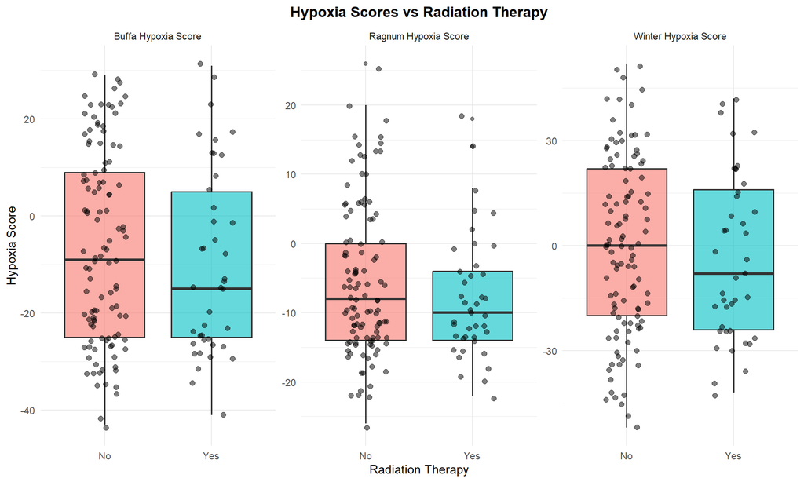

```r
# Hypoxia Data
data_hypoxia <- data_diag |>
  full_join(data_score, by = "Patient ID") |>
  select(PatientID = `Patient ID`,
         `Buffa Hypoxia Score`,
         `Ragnum Hypoxia Score`,
         `Winter Hypoxia Score`,
         `Radiation Therapy`,
         `Overall Survival (days)`,
         `Disease-specific Survival status (bin)`) |>
  drop_na("Buffa Hypoxia Score",
          "Ragnum Hypoxia Score",
          "Winter Hypoxia Score",
          "Radiation Therapy") |>
  rename(Status_Tumor = `Disease-specific Survival status (bin)`) |>
  pivot_longer(
    cols = c(
      `Buffa Hypoxia Score`,
      `Ragnum Hypoxia Score`,
      `Winter Hypoxia Score`
    ),
    names_to = "Hypoxia_Type",
    values_to = "Hypoxia_Score"
  ) |>
  group_by(Hypoxia_Type) |>
  mutate(
    hyp_med = median(Hypoxia_Score, na.rm = TRUE),
    Hypoxia_Group = case_when(
    Hypoxia_Score > hyp_med ~ "High Hypoxia Score",
    Hypoxia_Score <= hyp_med ~ "Low Hypoxia Score"
    )) |>
  ungroup()


# Plotting Distribution of Hypoxia Scores in Patients Receiving (or not) Radiation Therapy
ggplot(data_hypoxia, aes(
  x = `Radiation Therapy`,
  y = Hypoxia_Score,
  fill = `Radiation Therapy`
)) +
  geom_boxplot(alpha = 0.6) +
  geom_jitter(width = 0.2, alpha = 0.5) +
  facet_wrap(~ Hypoxia_Type, scales = "free_y") +
  theme_minimal() +
  theme(
    legend.position = "none",
    plot.title = element_text(hjust = 0.5, face = "bold")
  ) +
  labs(
    title = "Hypoxia Scores vs Radiation Therapy",
    y = "Hypoxia Score"
  )
```

- **Comparison of overall survival (days) of patients treated with radiotherapy depending on levels of hypoxia**

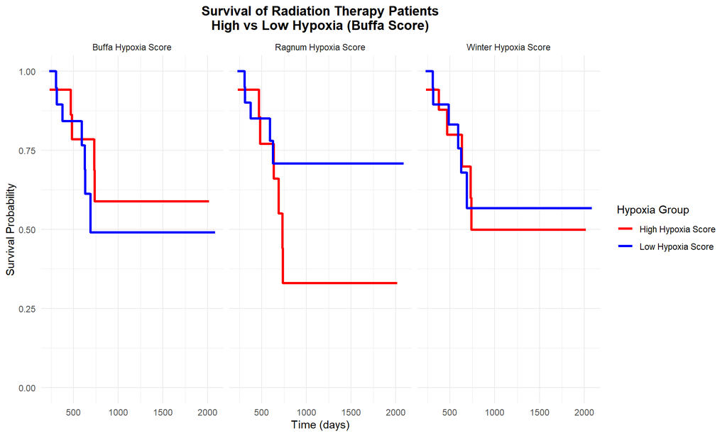

```r
# Hypoxia Data
data_hypoxia <- data_diag |>
  full_join(data_score, by = "Patient ID") |>
  select(PatientID = `Patient ID`,
         `Buffa Hypoxia Score`,
         `Ragnum Hypoxia Score`,
         `Winter Hypoxia Score`,
         `Radiation Therapy`,
         `Overall Survival (days)`,
         `Disease-specific Survival status (bin)`) |>
  drop_na("Buffa Hypoxia Score",
          "Ragnum Hypoxia Score",
          "Winter Hypoxia Score",
          "Radiation Therapy") |>
  rename(Status_Tumor = `Disease-specific Survival status (bin)`) |>
  pivot_longer(
    cols = c(
      `Buffa Hypoxia Score`,
      `Ragnum Hypoxia Score`,
      `Winter Hypoxia Score`
    ),
    names_to = "Hypoxia_Type",
    values_to = "Hypoxia_Score"
  ) |>
  group_by(Hypoxia_Type) |>
  mutate(
    hyp_med = median(Hypoxia_Score, na.rm = TRUE),
    Hypoxia_Group = case_when(
    Hypoxia_Score > hyp_med ~ "High Hypoxia Score",
    Hypoxia_Score <= hyp_med ~ "Low Hypoxia Score"
    )) |>
  ungroup()


# Survival Plot: High vs Low Hypoxia in Radiation therapy
# Filter only patients who received radiation therapy
data_rad_long <- data_hypoxia |>
  filter(`Radiation Therapy` == "Yes")

# Calculation of Kaplan-Meier
Kaplan_meier_data <- data_rad_long |>
  select(
    Hypoxia_Type,
    time = `Overall Survival (days)`,
    status = `Status_Tumor`,
    group = Hypoxia_Group
  ) |>
  arrange(Hypoxia_Type, group, time) |>
  group_by(Hypoxia_Type, group, time, status) |>
  tally() |>
  pivot_wider(
    names_from = status,
    values_from = n,
    values_fill = 0
  ) |>
  rename(events = `1`, censored = `0`) |>
  group_by(Hypoxia_Type, group) |>
  mutate(
    n_risk = rev(cumsum(rev(events + censored))),
    surv_step = 1 - events / n_risk,
    surv = cumprod(surv_step)
  ) |>
  ungroup()


# Plot tidyverse KM curve
ggplot(Kaplan_meier_data, aes(x = time,
                              y = surv,
                              color = group)) +
  geom_step(linewidth = 1.1) +
  scale_color_manual(
    values = c("High Hypoxia Score" = "red",
               "Low Hypoxia Score"  = "blue")) +
  scale_y_continuous(limits = c(0, 1)) +
  facet_wrap(~ Hypoxia_Type) +
  theme_minimal() +
  theme(
    plot.title = element_text(hjust = 0.5, face = "bold")
  ) +
  labs(
    title = "Survival of Radiation Therapy Patients\nHigh vs Low Hypoxia (Buffa Score)",
    x = "Time (days)",
    y = "Survival Probability",
    color = "Hypoxia Group"
  )
```

- **Overall Survival (days) based on different Hypoxia Scores/ Radiotherapy combinations**

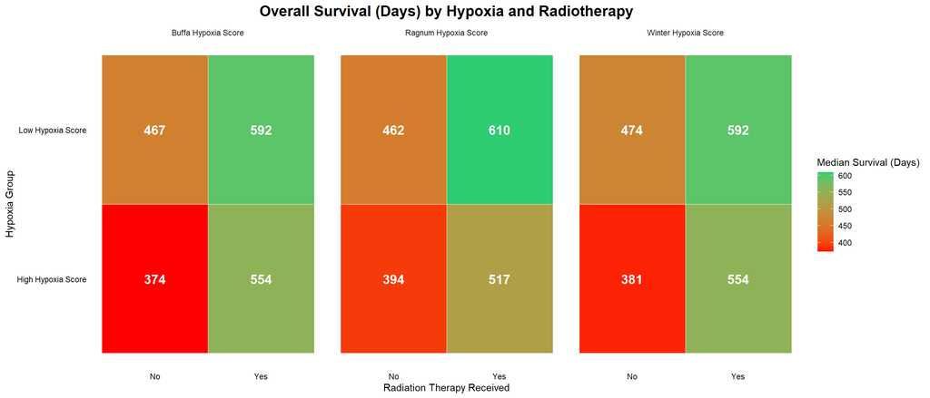

```r
# Data preparing
# Using the Hypoxia Data from before (already with the distinction high/low hypoxia score)
data_hypoxia <- data_hypoxia |>
  mutate(Radiation_Group = `Radiation Therapy`)

# Aggregate Data for Heatmap
# Group by the two variables and calculate the Median Overall Survival
data_heatmap_RT <- data_hypoxia |>
  group_by(Hypoxia_Type, Radiation_Group, Hypoxia_Group) |>
  summarise(
    Median_Survival = median(`Overall Survival (days)`),
    .groups = 'drop'
  )

# Plot Heatmap
ggplot(data_heatmap_RT, aes(x = Radiation_Group,
                            y = Hypoxia_Group,
                            fill = Median_Survival)) +
  geom_tile(color = "white") +
  geom_text(aes(label = str_c(round(Median_Survival, 0))),
            color = "white",
            size = 5,
            fontface = "bold") +
  scale_fill_gradient(
    low = "red",
    high = "#2ECC71",
    name = "Median Survival (Days)"
  ) +
  facet_wrap(~ Hypoxia_Type) +
  theme_minimal() +
  theme(
    plot.title = element_text(hjust = 0.5, face = "bold", size = 16),
    axis.text = element_text(color = "black"),
    panel.grid.major = element_blank(),
    panel.grid.minor = element_blank()
  ) +
  labs(
    title = "Overall Survival (Days) by Hypoxia and Radiotherapy",
    x = "Radiation Therapy Received",
    y = "Hypoxia Group"
  )
```

Hypoxia Scores are used to estimate how oxygen-deprived a tumor is based on gene expression. Higher scores indicate more severe hypoxia. Since hypoxic tumors tend to be more resistant to radiotherapy, these scores can be useful for understanding treatment response and patient outcomes. For this analysis, all three hypoxia scores wered used based on the diversity is score values.

From the plots analysis, across all three scoring methods (Buffa, Ragnum, and Winter), patients who received radiation therapy tended to have slightly lower hypoxia levels on average. This could suggest that clinicians may be considering hypoxia when choosing therapy, although the differences are not as significant as expected.

Survival analysis for radiotherapy-treated patients showed more distinct patterns depending on the specific hypoxia score:

- **Buffa Score:** Surprisingly, patients with higher hypoxia levels showed slightly better overall survival.
- **Ragnum Score:** Patients with lower hypoxia had a clear survival benefit, showing a strong difference between the low- and high-hypoxia groups.
- **Winter Score:** Lower hypoxia was also associated with better survival, though the difference was not as strong as with the Ragnum score.

The following analysis indicates that radiotherapy is most effective in tumors with low hypoxia, which aligns with the known link between hypoxia and radioresistance. Importantly, the data also show that patients with high-hypoxia tumors still gain a survival benefit from radiotherapy, performing better than untreated low-hypoxia cases. These results support the continued use of radiotherapy regardless of tumor hypoxia levels, due to its overall survival advantage.

Overall, these findings suggest that the relationship between tumor hypoxia, treatment decisions, and radiotherapy outcomes is more complicated than it might seem. The impact of hypoxia varies depending on which scoring method is used, highlighting the need for careful interpretation when linking hypoxia levels to clinical outcomes.

#### Kaplan-Meier survival analysis based on **Diagnosis Age**

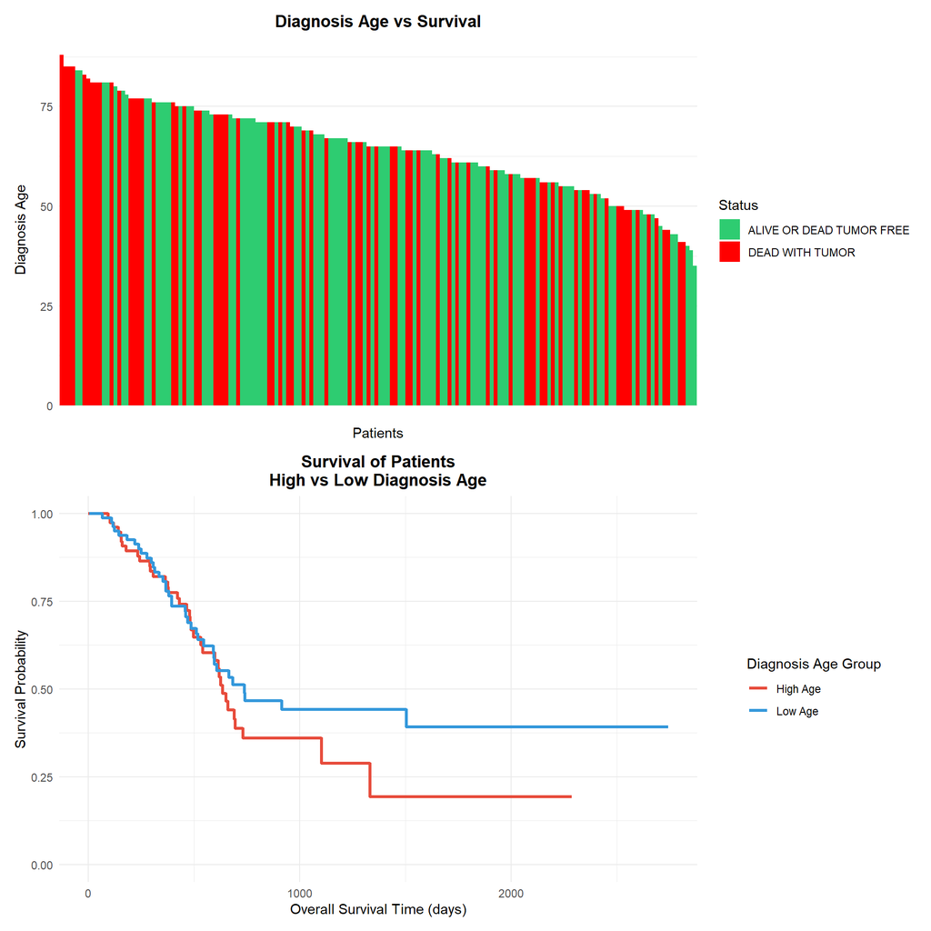

```r
## Preparing data - Select and clean necessary columns
data_age_surv <- data_metrics |>
  full_join(data_diag, by = "Patient ID") |>
  select(
    PatientID = `Patient ID`,
    Diagnosis_Age = `Diagnosis Age`,
    `Overall Survival (days)`,
    Status_Tumor = `Disease-specific Survival status (bin)`,
    Status = `Disease-specific Survival status (des)`
  ) |>
  drop_na(
    Diagnosis_Age,
    `Overall Survival (days)`,
    Status_Tumor,
    Status
  )

## PLOTTING WATERFALL
#  Colors to separate cancer status
status_colors <- c(
  "DEAD WITH TUMOR" = "red",
  "ALIVE OR DEAD TUMOR FREE" = "#2ECC71"
)

## Plotting
plt_age_surv <- data_age_surv |>
  arrange(desc(Diagnosis_Age)) |>
  mutate(Patient_Order = factor(PatientID,
                                levels = PatientID))|>
  ggplot(aes(x = Patient_Order,
             y = Diagnosis_Age,
             fill = Status)) +
  geom_col(width = 1) +
  scale_fill_manual(values = status_colors) +
  theme_minimal() +
  theme(axis.text.x = element_blank(),
        axis.ticks.x = element_blank(),
        panel.grid.major.x = element_blank(),
        plot.title = element_text(hjust = 0.5, face = "bold")) +
  labs(title = "Diagnosis Age vs Survival",
       x = "Patients",
       y = "Diagnosis Age")


## PLOTTING THE Kaplan-Meier
## Define Age Groups (Low vs High) using the median
age_med <- median(data_age_surv[["Diagnosis_Age"]], na.rm = TRUE)

data_age <- data_age_surv |>
  mutate(
    Age_Group = case_when(
      Diagnosis_Age > age_med ~ "High Age",
      Diagnosis_Age <= age_med ~ "Low Age"
    )
  )


# Survival Calculation (Kaplan-Meier)
## Calculation of Kaplan-Meier
Kaplan_meier_calc_age <- data_age |>
  select(
    time = `Overall Survival (days)`,
    status = Status_Tumor,
    group = Age_Group
  ) |>
  arrange(group, time) |>
  group_by(group, time, status) |>
  tally() |>
  pivot_wider(
    names_from = status,
    values_from = n,
    values_fill = 0
  ) |>
  rename(events = `1`, censored = `0`) |>
  group_by(group) |>
  mutate(
    # n_risk-> Calculate number at risk by summing all future events + censored
    n_risk = rev(cumsum(rev(events + censored))),
    # surv_step-> Calculate probability of survival at this time point
    surv_step = 1 - events / n_risk,
    # surv > Cumulative of surv_step gives the KM estimate
    surv = cumprod(surv_step)
  ) |>
  ungroup()

# Plot KM Curve
plt_km <- ggplot(Kaplan_meier_calc_age, aes(x = time,
                                  y = surv,
                                  color = group)) +
  geom_step(linewidth = 1.1) +
  scale_color_manual(
    values = c("High Age" = "#E74C3C",
               "Low Age" = "#3498DB") ) +
  scale_y_continuous(limits = c(0, 1)) +
  theme_minimal() +
  theme(
    plot.title = element_text(hjust = 0.5, face = "bold")) +
  labs(
    title = "Survival of Patients\nHigh vs Low Diagnosis Age",
    x = "Overall Survival Time (days)",
    y = "Survival Probability",
    color = "Diagnosis Age Group"
  )

plt_age_surv / plt_km
```

The comparison in the first plot is not very pronounced, although there is a slight tendency for higher diagnosis age to be associated with the ‘dead with tumor’ status, as expected. In contrast, comparing overall survival between high and low diagnosis age groups suggests that age at diagnosis may serve as a prognostic factor. While the difference is modest, the separation of the survival curves indicates that younger age at diagnosis is linked to a greater probability of long-term survival. This finding highlights age as an important variable to consider when evaluating patient prognosis.